# Análisis de Matriculas de Educación Superior

## Hito 3

Javiera Alegría, Adriana Concha, Erick Perez, Alonso Uribe

# Introducción

En el presente proyecto se busca poner en práctica los conocimientos adquiridos a lo largo del curso *Introducción a la Minería de Datos*, para ello se realizará un análisis de datos recogidos sobre *Matrículas de Educación Superior* entre los años 2010 y 2019. La fuente del set de datos corresponde al *Servicio de Información de Educación Superior* (SIES) y presenta un registro de 1.2 millones de matrículas aproximadamente por año, con información relacionada a nombre de la sede, región de la sede, rango de edad del matriculado, entre otros que se detallan más adelante.

La relevancia de estos datos radica en que, al realizar un análisis sobre ellos, podríamos obtener información que ayude a mejorar el acceso a la educación superior. Lo anterior, a través de información respecto a la demanda de educación y el cómo ésta se distribuye en la sociedad, lo que permitiría atacar de forma eficiente sesgos o problemáticas sociales inherentes a este proceso. También nos permite observar rasgos característicos que llevan a la deserción en la educación superior y, por ende, facilitar la búsqueda de soluciones a estos problemas.

# Análisis Exploratorio

En esta sección se describe el proceso realizado para adaptar el conjunto de datos, con el fin de poder trabajar con ellos, y, además, el proceso a través del cual se logró entender los datos y así plantearse preguntas acorde.

## Características del dataset inicial

- 10 archivos csv con información anual desde el 2010 al 2019
- Cada archivo cuenta con aproximadamente 1.2 millones de observaciones.
- 49 atributos por año.
- 29 nominales categóricos
- 3 nominales rankeadas
- 5 nominales arbitrarias
- 12 ordinales discretas

Esta información se obtuvo del documento disponible en la página de descarga de los datos, en él se describe cada columna y, en algunos casos, se indican los valores posibles. Además, para observar en detalle las columnas se utilizaron las siguientes funciones de la librería `Pandas`, el output se adjunta en la sección *Anexos, DataSet*;

```python
import pandas as pd
# df5 corresponde al DataFrame de Pandas en donde se cargaron los datos del año 2015
df5.info()
df5.describe()
df5.head(n=20)
for col in list(df5):
    df5[[col]].drop_duplicates()
```

Para comprender mejor el dataset, se graficó la cantidad de datos anuales y el porcentaje de datos nulos en cada año, ambos gráficos se muestran a continuación y sus códigos respectivos se muestran en la sección *Anexos, DataSet*.

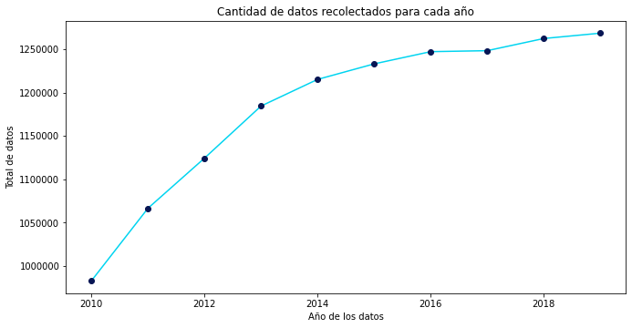

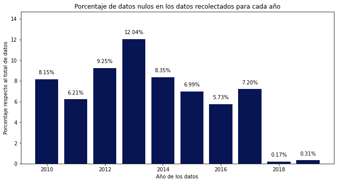

## Limpieza de los datos

En este ámbito se busca homogeneizar el tipo de dato para cada columna y la forma en que se representa un valor nulo a lo largo de todos los datos. De esta manera, se reemplazan las distintas formas de un dato nulo a el valor `Nan` de la librería `numpy` y se transforman los tipos de datos de las columnas a un solo tipo para cada una. El código principal se muestra en *Anexos, Limpieza de datos*.

## Correlación entre columnas

Desechamos ciertas columnas redundantes o con alta correlación, que a simple vista describen el mismo fenómeno con distintos niveles de detalle. Aún así, nos reservamos la posibilidad de utilizar cualquier columna que consideremos necesaria para futuros análisis. Este procedimiento, más que nada, es para hacernos una “*vista panorámica*” de la naturaleza de los datos, y con esto poder hacer preguntas más concretas.

Como en el dataset tenemos en su mayoría atributos nominales, con el propósito de observar alguna correlación entre ellos, los desplegamos mediante la vectorización “*One Hot Encoding*”, ésta consiste en representar el atributo como un vector de dimensión igual a la cantidad de valores distintos en dicho atributo, y asignar para cada valor un vector ortonormal a todos los demás. Luego de esto, fue posible generar una matriz de correlación con los valores desplegados de los siguientes atributos;

- `nivel_carrera_2`: Tipo de grado académico entregado por la carrera.
- `region_sede`: Región de la sede.
- `area_conocimiento`
- `tipo_inst_2`: Clasificación del tipo de institución
- `acreditada_carr`: Situación de acreditación de la carrera o programa informada por la institución al 30 de abril del año del proceso.
- `acreditada_inst`: Situación acreditación de institución al 30 de abril del año en proceso.
- `jornada`
- `rango_edad`
- `requisito_ingreso`
- `tipo_plan_carr`: Distinción dada por el tipo plan que posee la carrera o programa.
- `vigencia_carrera`: Tipo de vigencia.

El código a continuación permite obtener un heatmap de la correlación entre todos los años.

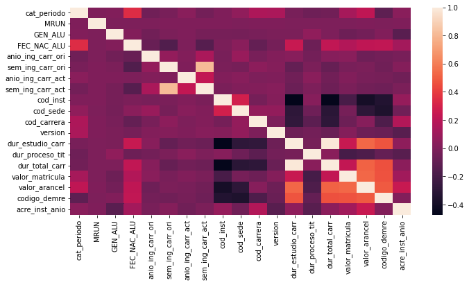

```python
import seaborn
df_all = pd.concat([df0, df1, df2, df3, df4, df5, df6, df7, df8, df9])
correlation = df_all.corr()
seaborn.heatmap(correlation)
```

Por otro lado, para aplicar *One Hot* a las columnas del año 2011, 2015 y 2019, primero se obtienen los tipos de cada columa en un dataframe, luego, para cada columna, se verfica si su tipo es `object` y si no corresponde a columnas con datos nominales arbitrarios o presentes en un solo año. Así, a las columnas que pasan el filtro se les aplica *One Hot* y se guarda su resultado en un archivo `.csv`. El código especifico se muestra en *Anexos, OneHot*.

En el bloque a continuación se seleccionan las columnas a utilizar del dataframe que no requieren ser transformadas, luego, se seleccionan las columnas que si requieren transformación y se quieren utilizar en la correlación. Entre ambos conjuntos se hace merge para obtener un solo DataFrame con toda la información.

```python
cols_to_drop = ["costo_obtencion_titulo_diploma", "costo_tit_explicacion_observacion", "costo_proceso_titulacion", "forma_ingreso", "nivel_global", "nivel_carrera_1", "comuna_sede", "provincia_sede", "area_carrera_generica", "oecd_area", "oecd_subarea", "tipo_inst_1", "tipo_inst_3", "modalidad"]
df_sub_one_hot = df_sub.drop(columns=cols_to_drop)

one_hot_cols = ["nivel_carrera_2", "region_sede", "area_conocimiento", "tipo_inst_2", "acreditada_carr", "acreditada_inst", "jornada", "rango_edad", "requisito_ingreso", "tipo_plan_carr", "vigencia_carrera"]
for col in one_hot_cols:
    df_aux = pd.read_csv("one_hot/one_hot_" + col + ".csv")
    df_sub_one_hot = pd.merge(df_sub_one_hot, df_aux, left_index=True, right_index=True)
```

Sobre el DataFrame obtenido se busca la correlación y el resultado se muestra en un HeatMap adjuntado en *Anexos, HeatMap de los datos*. Para una mejor comprensión del resultado a continuación se muestra la versión interactiva del HeatMap obtenido.

[figure not shown]

## Comportamientos de los datos

Como primera visualización es interesante analizar la distribución del costo de los aranceles entre las distintas regiones del país, como también el incremento de estos a lo largo de los años; para lo anterior se transforman los datos agrupando por rango de edad, genero y área de conocimiento, luego se cuenta la cantidad de aparaciones de cada triplete por año, por último se promedian los valores encontrados por año. El código para obtener los datos a graficar se adjunta en la sección *Anexos, Comportamiento de los datos*.

Así se obtiene la siguiente figura utilizando D3.js. Esta responde, finalmente, a la pregunta **¿Cómo se relaciona el área de conocimiento de la carrera con la edad y género de la persona que se matricula?**. En ella podemos ver una tendencia marcada que se condice con los roles de género establecidos socialmente.

Relación entre Área de conocimiento, edad y género

[figure not shown]

Para continuar comprendiendo los datos, nos planteamos la pregunta **¿Existe una correlación entre el costo de las carreras y su ubicación geográfica? ¿Varía esto a través de los años?**, para ello se selecciona el *código de la carrera*, *el valor del arancel* y *la región de la sede*, se eliminan los duplicados y se agrupan por región para obtener el promedio de los valores de arancel de las diferentes carreras. Lo anterior se hace para los años 2011, 2013, 2015, 2017 y 2019. Por último, se normaliza según la UF de cada año comprendiendo que los datos originales están en pesos chilenos y esta moneda se ve afectada por la inflación anualmente.

El código específico se muestra en la sección *Anexos, Comportamiento de los datos*. Con el fin de comprender mejor los datos finales, estos se expotaron al software Tableu para graficar.

[figure not shown]

Se extrae de la imagen que el valor (promedio) de los aranceles varían por región, siendo el valor más alto en la Región Metropolitana. También al analizar por año, se ve un incremento en Unidades de Fomento (UFs) del valor de los aranceles.

# Preguntas

1. ¿Se puede predecir las características de las matrículas para años futuros considerando los datos actuales?
2. ¿Cuáles son las características y tendencias de las personas que se cambian de carrera?
3. ¿Cuánto valor le agrega la acreditación a una carrera?
4. ¿Existe una relación entre costo de carrera y otras variables?

# Desarrollo de las preguntas

En esta sección se detallan la metodología planteada en el hito 2, la implementación de cada pregunta y los resultados obtenidos.

## Pregunta 1: ¿Se puede predecir las características de las matrículas para años futuros considerando los datos actuales?

**Esta pregunta está mayormente respondida y diseñada por Alonso Uribe**

### Metodología

Antes de esto hay que replantearse la pregunta, y para esto se debe definir concretamente cuáles son las características de las matrículas. En el caso de que fueran instancias, es decir, cada matrícula ingresada, entonces esta pregunta sería equivalente a la pregunta dos: debemos predecir características en personas, aunque en este caso no nos estaríamos centrando en personas que se cambian de carrera. En el caso de que fueran características macroscópicas, se deben evitar preguntas triviales, que involucren directamente indicadores como promedios, varianzas, número de sucesos, etc., que debieron ser estudiadas en el hito anterior. Una alternativa interesante podría ser generar clusters con los vectores totales (luego aplicar one hot) de cada instancia. y ver su evolución temporal: ¿dónde está el centro de cada uno, por año?, ¿cómo van cambiando ciertos indicadores de validación: Inercia, Separación, Cohesión,?, ¿cómo va cambiando la densidad de clusters?. Junto a esto podemos ir comparando con valores más tangibles como promedios, varianzas, etc. (ej: varianza regional del valor de arancel).

Para responder esta pregunta, se deben completar tres pasos previos:

1. Utilizar nuevamente como vectorización preliminar one hot encoding para ingresar las instancias como vectores de dimensión igual al número de columnas. Habrá que tener cuidado interpretando los clusters y el espacio vectorial en el que residen. En este vector, por ejemplo, la columna de rango de edad (ej: 18 y 20 años) tendría igual peso que la del tipo de estudio superior (ej: Doctorado); los dos marcarían un 1 en su dimensión correspondiente, y en las demás, de su misma naturaleza, un 0.
2. Generar **Clustering** con ciertos atributos seleccionados gracias a la exploración realizada en el hito 1. Con esto, y la correspondiente validación del clustering, podremos cuantificar potenciales patrones de agrupación.

   2.1 Primeramente se utilizará el **Coeficiente de Silhouette** para verificar la viabilidad del cluster, si fuese negativo, se trataría de generar un vector (por instancia) preliminar compuesto de otra manera, o también podría ser interesante crear para cada columna un vector y comprobar si podemos, mediante algún tipo de operación, unificarlos todos, de forma que el clustering de cuenta de estructuras particulares.

   2.2 Se hará uso de la métrica **Cohesión**, **Separación** e **Inercia**, junto a la visualización de su **Matriz de proximidad**, una vez encontrado un coeficiente de Silhouette positivo, con el propósito de seguir evaluando las estructuras subyacentes en los datos.

   2.3 Podemos tomar este proceso como una forma sistemática de vectorizar instancias, de modo que luego quedar satisfechos (o de plano probar con varias) con un encoding podremos proseguir al paso 3.
3. Luego de tener un vector para cada instancia, podemos reducir su dimensionalidad y visualizar los clusters, como primera opción mediante PCA, pero existen varias por explorar. Luego de esto tendremos instancias medianamente interpretables, y que facilitarán su manejo en algoritmos de Regresión. Como ya se dijo en un inicio, otro posible estudio es el de la dinámica de los cluster, sus propiedades (ej: su densidad), y la correlación que estas variables guardan con indicadores macroscópicos en las matrículas(ej: valor arancel medio, arancel medio por región, etc.).

### Implementación

El grueso del código quedará en anexo. Enseguida, se describe a grandes rasgos la implementación.

Se selecciona nuevamente una colección de columnas relevantes para nuestra pregunta, como criterio de selección se consideran las que se puedan relacionar menos con instancias particulares y más con caracteristicas macroscopicas en el año de matriculas.  
Se genera un enconding para cada una de las columnas categoricas, dado valores ordinales a las columnas, para luego facilitar la conversión a one-hot enconding. Este one-hot consiste en un solo vector de ceros y unos, el que recopila todas las columnas.  
Teniendo estos vectores, se explora diferentes métodos de clustings, se selecciono K-Means, al dar los mejores resultados (aún asi deficientes) en Coef. de Silhouette, se encontró el número óptimo de clusters mediante el método del "codo". El clustering es exclusivamente realizado en espacio **One-hot**, no se ahonda en el movimiento realizado en otros espacios.

**Método del "codo"** entrega cualitativamente **20 clusters**.  
**Coef. de Sillhouete** de **Clustering Jerarquico(ward)**: $-0.05$ en espacio **PCA**; $0.05$ en espacio **One-hot**.  
**Coef. de Sillhouete** de **KMeans**: $-0.02$ en espacio **PCA**; $0.10$ en espacio **One-hot**.  
**Coef. de Sillhouete** de **DBSCAN**: $-0.72$ en espacio **PCA**; $-0.13$ en espacio **One-hot**. (Para este último el método de la "rodilla" no funcionaba)

El seguimiento de los clusters a través de los años corresponde al desafio más importante de nuestro experimento. Para esto, los cluster se etiquetaron al seleccionar una columna relevante (arbitraria), y a cada cluster se le asigna el lugar n-ésimo en un contador de apariciones de un valor (nuevamente arbitrario) de la columna. De esta forma tenemos algún criterio para hacer un seguimiento a través de los años. Este criterio puede ser mayormente teorizado para mejorar la interpletabilidad del movimiento y su correlación con variables macroscópicas.  
Enseguida se generó otro enconding mediante PCA (no se profundizo en la busqueda de métodos más avanzados de enconding). Como el proceso de PCA desde un enconding One-hot es costoso, se trabaja con una porción aleatoria de instancias de cada año. El año tiene alrededor de $10^6$ de instancias, se saco una muestra de $10^4$ instancias.

Luego, para cada año se grafica un scatterplot de los clusters etiquetados en estacio **One-hot**, genera una **Matriz de Proximidad** y, a su vez, se hace un seguimiento de cada cluster por separado, estos dos en **espacio PCA**.

##### **Clustering y Matriz de Porximidad para 2010.**

[figure not shown]

##### **Clustering y Matriz de Porximidad para 2015.**

[figure not shown]

##### **Movimiento del cluster n° 2, 14 y 17 (izquierda a derecha) desde el año 2010 al año 2019.**

[figure not shown]

Avanzando en la metodología quedo claro como su desarrollo resulto ser más complejo de lo que se pensaba. Entendemos que hay un largo trecho para obtener resultados contundentes de correlación entre este "movimiento" de clusters y las caracteristicas macroscópicas de las matriculas. Por lo tanto, planteamos formas de seguir perfeccionando el model:

- Principal es crear una métrica confiable que relacione el movimiento (2D) de los centroides con la variable a correlacionar y, en última instancia, predecir.
- Generar un criterio de "seguimiento" de clusters por año más interpretable y menos arbitrario, es decir, seleccionar columnas y valores que puedan ir en directa relación con la variable macroscópica a predecir.
- Alcanzar una base teorica que haga explicita la dependencia entre clusters y variables macroscópicas. Dada la dificultad de esta tarea, y como conclusión general de esta experiencia, es obligada la exploración de métodos más convencionales y asentados para una resolución de problemas más eficiente y economica.

## Pregunta 2: ¿Cuáles son las características y tendencias de las personas que se cambian de carrera?

**Esta pregunta está mayormente respondida y diseñada por Javiera Alegria**

### Metodología

Para responder la pregunta 2 primero es importante notar que es posible determinar quienes se han cambiado de carrera con los datos actuales, por lo tanto, se utilizará clasificación para buscar perfiles de personas que podrían cambiarse de carrera en el futuro. Así, las clases posibles son “se cambió de carrera” y “no se cambió de carrera”, y nuestra clase positiva corresponde a quienes sí se han cambiado de carrera, pues es lo que queremos evitar.

Entonces lo primero es disminuir la dimensionalidad de los datos, para esto se agregará una nueva columna que describe el tiempo que lleva la persona cursando su carrera actual, así esta resume la información de las columnas `cat_periodo` y `ANIO_ING_CARR_ACT`, su creación sería a través de la resta de los años de `ANIO_ING_CARR_ACT` y `cat_periodo`. Por otro lado, se requiere una columna que indique la clase de la fila, la que resumiría la información de las columnas `ANIO_ING_CARR_ORI` y `ANIO_ING_CARR_ACT`; para obtenerla haremos una restricción con la siguiente query: `row.cat_periodo != row.anio_ing_carr_ori and row.cat_periodo == row.anio_ing_carr_act`. De igual manera, se utiliza la información de `NIVEL_GLOBAL` para limitar los datos a las matriculas de pregrado, pues solo aquí tiene sentido el análisis.

Adicionalmente se mantendremos las siguientes columnas; `GEN_ALU`, `RANGO_EDAD`, `TIPO_INST_3`, `JORNADA`, `TIPO_PLAN_CARR`, `DUR_ESTUDIO_CARR`, `NIVEL_CARRERA_1`, `VALOR_MATRICULA`, `VALOR_ARANCEL`, `OECD_AREA`, `ACREDITADA_CARR`, `ACREDITADA_INST`. Donde se incluye una sola columna relacionada a la duración de la carrera pues se observa una estrecha relación entre DUR_ESTUDIO_CARR y DUR_TOTAL_CARR; una correlación de 0.99. A pesar de esto siguen siendo demasiadas columnas, por lo que aplicaremos la transformación One Hot sobre los datos restringidos y eliminaremos las columnas que tengan correlación cercana a 1 o a -1.

Una vez determinadas las columnas a utilizar se busca encontrar el mejor algoritmo de clasificación, para lo cual se evaluarán las métricas de los algoritmos **KNN**, **Naive Bayes**, **Support Vector Machine** y **Árbol de Decisión**. Estas métricas serán evaluadas con la técnica **holdout**, dejando $1/3$ de los datos para entrenar y aplicando estratificación sobre las particiones, pero, además, se observará el desempeño aplicando **subsampling** sobre la clase negativa, **oversampling** sobre la clase positiva y el caso en que no se aplica ninguno, esto al considerar que son pocos los alumnos que se cambian de carrera anualmente.

Por último, usaremos matriz de confusión para observar el desempeño, poniendo especial atención en la métrica **recall**, dado que no es un gran problema tener falsos positivos, pues lo que se busca es mejorar la información entregada a estudiantes previo a su primera matrícula, considerando quienes tienen un perfil con mayor probabilidad de deserción de su primera carrera.

### Implementación

```python
# df_0to7 corresponde al dataframe con los datos de los años 2010 hasta 2017

# Selección de columnas
sub_df_0to7 = df_0to7[["GEN_ALU", 'cat_periodo', 'anio_ing_carr_ori', 'anio_ing_carr_act', "rango_edad", "tipo_inst_3", "jornada", "tipo_plan_carr", "dur_estudio_carr", "nivel_carrera_1", "nivel_global", "oecd_area", "acreditada_carr", "acreditada_inst"]]

# Restricción a solo datos de pregrado
sub_df_0to7 = (sub_df_0to7.query("nivel_global=='Pregrado' or nivel_global.isnull()")
                         .drop(columns = ['nivel_global'])
                         .dropna(subset=['anio_ing_carr_act']))

sub_df_0to7['anio_en_carr_actual'] = sub_df_0to7['anio_ing_carr_act'] - sub_df_0to7['cat_periodo']

# se pide que cat_periodo == anio_ing_carr_act para no contar a una misma persona todos los años
sub_df_0to7['Class'] = sub_df_0to7.apply(lambda row: row.cat_periodo != row.anio_ing_carr_ori and row.cat_periodo == row.anio_ing_carr_act, axis = 1)
sub_df_0to7 = sub_df_0to7.drop(columns = ['anio_ing_carr_ori', 'cat_periodo', 'anio_ing_carr_act'])

sub_df_0to7['acreditada_carr'] = sub_df_0to7['acreditada_carr'].replace('NO ACREDITADA', False, regex=True)
sub_df_0to7['acreditada_carr'] = sub_df_0to7['acreditada_carr'].replace('ACREDITADA', True, regex=True)
sub_df_0to7['acreditada_inst'] = sub_df_0to7['acreditada_inst'].replace('NO ACREDITADA', False, regex=True)
sub_df_0to7['acreditada_inst'] = sub_df_0to7['acreditada_inst'].replace('ACREDITADA', True, regex=True)
```

Con el fin de analizar la correlación entre columnas, se genera un HeatMap con los datos, el resultado se muestra a continuación, mientras que el código se muestra en la sección *Anexos, Implementación, Pregunta 2*.

[figure not shown]

```python
# se eliminan columnas con correlación alta y se eliminan las filas que puedan haber quedado con valores nulos
df_sub_one_hot = df_sub_one_hot.drop(columns = ['tipo_plan_carr_Plan Regular', 'jornada_Diurno', 'acreditada_carr_False']).dropna()
```

Para analizar el comportamiento con *oversampling*, *subsampling* y con los *datos normales* se crearon dos funciones basandose en el código del *laboratorio 2*; `get_data_dict(df, testSize)` que genera un diccionario con los conjuntos de testeo y de cada tipo de entrenamiento, y `train(Classifier, data_dict)` que recibe el diccionario anterior y un clasificador, y retorna tres clasificadores entrenados con cada uno de los conjuntos, e imprime sus métricas. Estas funciones se adjuntan en la sección *Anexo, Implementación, Pregunta 2*.

Los resultados de las métricas obtenidos para cada clasificador se adjuntan en la tabla siguiente y los códigos en la sección *Anexos, Implementación, Pregunta 2*.

[figure not shown]

Notemos que *SVM* no se pudo terminar de ejecutar pues requiere demasiados recursos.

Se observa que *SVM* y *KNN* utilizan muchos recursos de la máquina para tan pocos datos, además, en general las métricas de *KNN* no presentan una mejora considerable a comparación de *Naive Bayes* y *Árbol de Decisión*, y *SVM* presenta muy malos resultados en especial respecto a la métrica *recall* de la clase verdadera. Así, se descartan tanto *SVM* como *KNN* para entrenar con todos los datos. A partir de aquí se entrenan los calsificadores con el $30\%$ de los datos, lo que implica $1288824$ datos para el caso del *oversampling* de la clase verdadera y $133669$ datos para el caso del *subsampling* sobre la clase falsa.

Los resultados se adjuntan en la tabla siguiente, mientras que el código se adjunta en la sección *Anexo, Implementación, Pregunta 2*.

[figure not shown]

Con lo anterior vemos que el clasificador **Árbol de Decisión** con *Oversampling* y con *Subsampling* presenta iguales y mejores métricas, pues si bien Naive Bayes alcanza un recall de $0.96$, a su vez presenta una precisión demasiado baja, de $0.32$. Al observar detenidamente las metricas de *Árbol de Decisión* con *Oversampling* y con *Subsampling* vemos una ligera diferencia que nos permite decidir por **Árbol de Decisión** con **Oversampling**. Así, hemos obtenido un clasificador capaz de identificar a personas que se cambiarán de carrera, de modo que se pueden implementar medidas para prevenir dicha situación y, de esta manera, ayudar al futuro de los estudiantes.

## Pregunta 3: ¿Cuánto valor le agrega la acreditación a una carrera?

**Esta pregunta está mayormente respondida y diseñada por Erick Perez**

### Metodología

La dificultad de esta pregunta radica en definir el concepto de **valor** y preprocesar los datos de manera favorable, que faciliten el análisis con esto en mente se presenta la siguiente metodología por pasos.

- Definir columnas numéricas a utilizar: Se eligen `VALOR_ARANCEL`, `GEN_ALU`,`FEC_NAC_ALU`, `ANIO_ING_CARR_ORI`, `CAT_PERIODO`, `DUR_TOTAL_CARR`, `ACRE_INS_ANIO`, `ACRE_INS_DESDE_HASTA`. Estas columnas describen de buena forma las carreras, sus periodos de acreditación y precios, caracterizando también a sus alumnos. Los datos se manejan en forma de DataFrames de pandas, y realizando un subset de las columnas de interés.
- Definir columnas categóricas a utilizar: Se eligen `TIPO_INS_2`, `NOMB_INST`,`CINE_F_13_AREA`, `ACREDITADA_CARR`, `NIVEL_CARR_2`, `REGION_INST`. De la misma forma que el punto anterior, se agregan estas columnas al filtrado quedando un total de 14 columnas, achicando así la cantidad de datos a procesar, recordando que el dataset original contiene 49 columnas.
- Preprocesado: Creación de nuevas columnas para obtener información util.
  - `EDAD_ALU`: Edad del estudiante al cual corresponde la matrícula, hace más directo el análisis de datos, variable numérica.
  - `ANIOS_U`: Años que el estudiante lleva en la universidad, hace más directo el filtrado de datos, variable numérica.
  - `ANIOS_RESTANTES ACRE`: Años que restan para que acabe la acreditación de la carrera, variable numérica.
- Preprocesado: Modificación de variables.
  - `GEN_ALU`: Se cambia la variable de numérica a categórica.
  - `ACRE_INST_ANIO`: Se modifican los valores nan por 0.
  - Se dejan fuera del análisis las matrículas con valores nan, o irregulares, en alguna columna, que representan menos del 1%.
- Se obtienen histogramas de cada una de las variables (o columnas), diferenciando entre cuenta de acreditados y no acreditados, con el fin de analizar singularidades.
- Se obtienen métricas estadísticas de los histogramas como media, mediana y desviación estandard.
- Se analiza mediante gráficos (matplotlib) la evolución de los estadisticos durante los años desde 2011 al 2018. Adicionalmente se analiza la incorporación de alumnos nuevos a carreras específicas que durante esste tiempo pierdan su acreditación. Lo mismo anterior anallizando el valor de matrícula de estas carreras.
- Se realiza clustering (kmeans y herárquico), sumado a metodos de reducción de dimencionalidad (PCA , t-sne y UMAP), para caracterizar y visualizar las particularidades de la acreditación y como se agrupan distintas instituciones y carreras.

### Implementación

#### Preprocesado

Se crean 2 funciones `seleccionar_cols()` y `modificar_cols()`. En la primera se seleccionan características que, a priori, tienen relación con el arancel y aportan al análisis. La segunda utiliza las columnas seleccionadas para modificar algunas, y también crear otras columnas nuevas a partir de algunas existentes, con el fin de obtener información más útil.

Con esto se seleccionan 13 columnas de 49 con `seleccionar_cols()`.

Con `modificar_cols()` se modifican las columnas:

- `GEN_ALU`: Se cambia la variable de numérica a categórica.
- `ACRE_INST_ANIO`: Se modifican los valores nan por 0.
- `DUR_TOTAL_CARR`: Se modifican las unidades, pasa de ser duración en semestres a duración en años.

También se crean 2 nuevas columnas:

- `EDAD_ALU`: Edad del estudiante al cual corresponde la matrícula, hace más directo el análisis de datos, variable numérica.
- `ANIOS_U`: Años que el estudiante lleva en la universidad, hace más directo el filtrado de datos, variable numérica.

```python
cols = ['tipo_inst_2','nomb_inst','region_sede','nivel_carrera_2','cine_f_13_area',
            'acreditada_carr','cat_periodo','GEN_ALU','FEC_NAC_ALU','anio_ing_carr_ori',
            'dur_total_carr','valor_arancel','acre_inst_anio']

    anios = [2011,2012,2013,2014,2015,2016,2017,2018]

    for anio in anios:
        filename = f'data/{anio}.csv'
        seleccionar_cols(filename ,anio ,cols)
        filename = f'data_acre/data_acre_{anio}.csv'
        modificar_cols(filename , anio)
```

Se realiza para cada uno de los años desde 2011 a 2018, se guardan los dataframe en nuevos archivos `.csv` lo que permite un mejor manero posterior, con archivos más livianos.

#### Histogramas

De las 15 columnas obtenidas en la parte anterior se decide continuar sólo con 11: 10 destinadas a obtener histogramas, y 1 columna que indica si la carrera está acreditada o no. De las 10 columnas, 5 son categóricas y 5 numéricas, se crean 2 funciones para plotear los histogramas de cada tipo: `histogramasCategoricas()` y `histogramasNumericas()`.

```python
#Ejemplo de dataframe
    anio = 2011
    filename = f'data_acre/modif_acre_{anio}.csv'
    df = pd.read_csv(filename, error_bad_lines=False)

    df.head()
```

|  | tipo_inst_2 | region_sede | nivel_carrera_2 | cine_f_13_area | GEN_ALU | acreditada_carr | dur_total_carr | valor_arancel | edad_alu | acre_inst_anio | anios_U |
| --- | --- | --- | --- | --- | --- | --- | --- | --- | --- | --- | --- |
| 0 | Centros de Formación Técnica | Metropolitana | Carreras Técnicas | Salud y Bienestar | femenino | NO ACREDITADA | 2.5 | 400000.0 | 24 | 0.0 | 0 |
| 1 | Centros de Formación Técnica | Metropolitana | Carreras Técnicas | Artes y Humanidades | femenino | ACREDITADA | 4.0 | 1628000.0 | 21 | 0.0 | 0 |
| 2 | Centros de Formación Técnica | Antofagasta | Carreras Técnicas | Servicios | femenino | NO ACREDITADA | 2.5 | 912000.0 | 18 | 0.0 | 1 |
| 3 | Centros de Formación Técnica | Antofagasta | Carreras Técnicas | Administración de Empresas y Derecho | femenino | NO ACREDITADA | 2.5 | 840000.0 | 17 | 0.0 | 1 |
| 4 | Centros de Formación Técnica | Antofagasta | Carreras Técnicas | Administración de Empresas y Derecho | femenino | NO ACREDITADA | 2.5 | 840000.0 | 20 | 0.0 | 1 |

Cabe destacar que en `histogramasNumericas()` también hay modificación de datos, donde la columna `DUR_TOTAL_CARR` pasa a ser tipo entero, y `VALOR_ARANCEL` ahora está discretizada en tramos de 500,000 $CLP. Aquí también se toman estadísticos de las columnas que son consideradas más útiles, de `VALOR_ARANCEL` se toma el promedio y la desviación estándar, de `ANIOS_U` se guarda la cantidad normalizada de matriculas nuevas acreditadas y no acreditadas. Estos estadísticos se cuardan en un archivo llamado `valores_temporales.csv` para ser trabajados más adelante.

[figure not shown]

#### Evolución Temporal

Se grafican los estadísticos importantes para analizar, de manera visual, evolución de estos desde el 2011 al 2018.

|  | 2011 | 2012 | 2013 | 2014 | 2015 | 2016 | 2017 | 2018 |
| --- | --- | --- | --- | --- | --- | --- | --- | --- |
| mean_no_ac | 2.00 | 2.2 | 2.20 | 2.30 | 2.40 | 2.4 | 2.50 | 2.50 |
| mean_ac | 2.50 | 2.5 | 2.60 | 2.70 | 2.80 | 2.9 | 3.10 | 3.10 |
| std_no_ac | 1.10 | 1.3 | 1.20 | 1.20 | 1.30 | 1.4 | 1.40 | 1.40 |
| std_ac | 1.10 | 1.2 | 1.20 | 1.40 | 1.40 | 1.4 | 1.40 | 1.40 |
| nuevos_no_ac | 0.76 | 0.7 | 0.67 | 0.64 | 0.55 | 0.5 | 0.43 | 0.45 |
| nuevos_ac | 0.24 | 0.3 | 0.33 | 0.36 | 0.45 | 0.5 | 0.57 | 0.55 |

[figure not shown]

#### Análisis

No todas las columnas muestran información relevante para ser utilizada directamente con la acreditación de una carrera. En primera instancia es bueno inspaccionar sólo las columnas más relevantes, sin embargo no se descarta la idea de que el trabajo no supervisado (como clustering) sea útil para encontrar mejores relaciones con carreras acreditadas vs no acreditadas.

Se destaca que para ciertas áreas de carreras se ha vuelto muy relevante en este periodo la acreditación, en particular en Derecho, Ingeniería y Salud a cambiado drasticamente la cantidad de matriculas en carreras acreditadas vs. no acreditadas. Esto hace pensar que si hay un valor para las carreras de estas áreas estar acreditadas, ya que pueden pertenecer al grupo de las más demandadas que es hacia donde se está moviendo la balanza. En el caso de Educación, no ha cambiado en los últimos años la relación, esto puede dar indicios de que en ciertas áreas no hay motivación de pasar de estado no acreditado, a acreditado.

En cuanto al valor del arancel de las carreras, las que están acreditadas efectivamente tienen mayores aranceles. La brecha entre aranceles no aumenta significativamente durante los años de estudio. Que los aranceles sean mayores no implica que una carrera, al acreditarse, pueda optar a cobrar aranceles más altos, para esto se necesita información adicional, queda propuesto hacer seguimiento del valor del arancel de carreras que pasan de estar No Acreditasas a Acreditasas, y viceversa, para poder concluir de mejor forma.

## Pregunta 4: ¿Existe una relación entre costo de carrera y otras variables?

**Esta pregunta está mayormente respondida y diseñada por Adriana Concha**

### Metodología

Siguiendo la sugerencia del cuerpo docente para el Hito 2 y aplicando las nuevas técnicas de minería de datos aprendidas en el curso desde entonces, se decidió responder esta pregunta utilizando **Reglas de asociación**. En la iteración anterior se propuso utilizar clustering, sin embargo, la búsqueda de reglas de asociación se adapta mejor a la búsqueda de relaciones entre variables. El objetivo de esta pregunta es extraer reglas y relaciones entre la variable valor del arancel y otras variables de las matrículas de educación superior , para poder realizar un análisis sobre éstas.

Propuesta experimental:

- Se toma como input los datos para el año 2019, filtrando valores faltantes.
- Se seleccionan los atributos: `jornada`, `rango_edad`,`dur_total_carr`,`tipo_inst_3`,`area_conocimiento`, `region_sede`, `acreditada_inst`, `valor_arancel`, `valor_matricula`.
- Se categoriza el valor de arancel en tres parámetros:
  - Percentil 0 al 32: Arancel bajo (AB)
  - Percentil 33 al 66: Arancel medio (AM)
  - Percentil 67 al 100: Arancel alto (AA)
- Se categoriza el valor de la matrícula en tres parámetros:
  - Percentil 0 al 32: Matrícula baja (MB)
  - Percentil 33 al 66: Matrícula media (MM)
  - Percentil 67 al 100: Matrícula alta (MA)
- Se utiliza el algoritmo ECLAT para obtener los itemsets más frecuentes, con **support** sobre 4%.
- Se utiliza el **algoritmo apriori** para generar reglas de asociación sobre los itemsets más frecuentes. Específicamente, se buscan reglas de asociación con cada categoría de Arancel en el consecuente. Se utiliza el parámetro minlen igual a 2, para encontrar reglas de al menos 2 elementos.
- Se utiliza como validación las métricas **support** sobre 4% y **confidence** sobre 30%. Además, se ordenan las reglas generadas de acuerdo a su **lift**, para conocer la efectividad de las predicciones. Para esta pregunta, nos interesan aquellas reglas con lift superior a 1.
- A partir de los resultados obtenidos, se generan las siguientes visualizaciones:
  - Scatterplots para comparar confidence, support y lift para las reglas generadas.
  - Grafos para visualizar los principales items que llevan a cada categoría de arancel.

### Implementación

La implementación en detalle de esta pregunta se puede ver en *Anexos, Implementación, Pregunta 4*. Se utilizaron 1268504 registros para el año 2019, añadiendo las categorías para valor de arancel y de matrícula.

| jornada | rango_edad | dur_total_carr | tipo_inst_3 | area_conocimiento | region_sede | acreditada_inst | Categoria_arancel | Categoria_matricula |
| --- | --- | --- | --- | --- | --- | --- | --- | --- |
| Diurno | 15 a 19 años | 10 | Universidades Privadas | Salud | Coquimbo | ACREDITADA | AM | MA |
| Diurno | 20 a 24 años | 10 | Universidades Estatales CRUCH | Ciencias Sociales | Metropolitana | ACREDITADA | AA | MM |
| Diurno | 25 a 29 años | 10 | Universidades Privadas CRUCH | Humanidades | Metropolitana | ACREDITADA | AA | MB |
| Vespertino | 15 a 19 años | 5 | Institutos Profesionales | Administración y Comercio | Metropolitana | NO ACREDITADA | AB | MB |
| Vespertino | 20 a 24 años | 5 | Institutos Profesionales | Administración y Comercio | Metropolitana | ACREDITADA | AB | MM |
| Diurno | 20 a 24 años | 10 | Universidades Estatales CRUCH | Tecnología | Metropolitana | ACREDITADA | AA | MM |

Se obtuvieron los siguientes items más frecuentes con el algoritmo ECLAT.

| items | support | count |
| --- | --- | --- |
| {ACREDITADA} | 0.93 | 1174652 |
| {Diurno} | 0.70 | 892899 |
| {ACREDITADA,Diurno} | 0.68 | 860341 |
| {Metropolitana} | 0.48 | 613381 |
| {20 a 24 años} | 0.47 | 598695 |
| {20 a 24 años,ACREDITADA} | 0.46 | 578644 |

Utilizando el algoritmo **APRIORI** se generaron 8484 reglas, con support mayor a 4% y confidence mayor a 30%. Como se observa en el gráfico de dispersión, la mayoría de las reglas poseen un support menor al 20%.

[figure not shown]

Dentro de las reglas generadas, se identificaron las siguientes reglas que llevan como consecuente a un Arancel Alto. Por ejemplo, de esto se puede concluir con un 4% de support y 92% de confidence, que una matrícula en una Universidad Privada, Acreditada, Diurna, en el área de la Salud con una Matrícula alta, lleva a tener un Arancel Alto. Esto con un lift de 2.76.

| rules | support | confidence | coverage | lift | count |
| --- | --- | --- | --- | --- | --- |
| {ACREDITADA,Diurno,MA,Salud,Universidades Privadas} => {AA} | 0.04 | 0.92 | 0.05 | 2.76 | 56737 |
| {Diurno,MA,Salud,Universidades Privadas} => {AA} | 0.05 | 0.92 | 0.05 | 2.75 | 58413 |
| {10,ACREDITADA,Diurno,MA,Metropolitana} => {AA} | 0.05 | 0.91 | 0.06 | 2.73 | 66365 |
| {ACREDITADA,MA,Salud,Universidades Privadas} => {AA} | 0.05 | 0.91 | 0.05 | 2.73 | 57557 |
| {10,ACREDITADA,MA,Metropolitana} => {AA} | 0.05 | 0.91 | 0.06 | 2.72 | 69277 |
| {10,ACREDITADA,Diurno,MA,Metropolitana,Universidades Privadas} => {AA} | 0.04 | 0.90 | 0.05 | 2.70 | 55948 |

Por otra parte, se identificaron las siguientes reglas que implican un Arancel Bajo. Por ejemplo, con un lift de 3, support 4% y confidence 100%, se puede concluir que una matrícula en una carrera de 5 años, en un Instituto Profesional con matrícula baja, implicará un Arancel Bajo.

| rules | support | confidence | coverage | lift | count |
| --- | --- | --- | --- | --- | --- |
| {5,Institutos Profesionales,MB} => {AB} | 0.04 | 1.00 | 0.04 | 3.00 | 54192 |
| {5,Centros de Formación Técnica,MB} => {AB} | 0.05 | 0.99 | 0.05 | 2.97 | 63287 |
| {5,ACREDITADA,Centros de Formación Técnica,MB} => {AB} | 0.04 | 0.99 | 0.04 | 2.97 | 55721 |
| {5,Diurno,MB} => {AB} | 0.05 | 0.99 | 0.05 | 2.97 | 62959 |
| {5,ACREDITADA,Diurno,MB} => {AB} | 0.04 | 0.99 | 0.04 | 2.96 | 54118 |
| {5,MB} => {AB} | 0.10 | 0.98 | 0.11 | 2.96 | 131416 |

En la siguiente visualización, se pueden ver las relaciones entre las Top 50 reglas generadas, con mayor lift, para consecuente Arancel Bajo. Se observa que los mayores lift se obtienen a partir de precedentes Área: Administración y Comercio, Matrícula baja y Centros de formación técnica. Los métodos A Distancia, a pesar de su bajo support, también presentan un lift alto para generar Arancel Bajo.

[figure not shown]

# Conclusiones

Por otro lado, analizando el desarrollo del proyecto, consideramos que las herramientas entregadas en el curso fueron de gran utilidad. Sin embargo, subestimamos la inversión en tiempo y recursos que conlleva usar estas herramientas para encontrar las respuestas a nuestras preguntas, tal como se observa en las preguntas 1 y 2.

# Trabajo futuro

Si bien se lograron conclusiones importantes, esto no implica que no exista margen de mejora. Así, como desafío a futuro, se espera analizar nuevamente la relación entre las variables estudiadas, a través de los años, considerandfo también cómo se relaciona la modalidad remota con el valor de arancel para los años 2020 y 2021. Además, queda propuesto hacer un seguimiento de las carreras que cambian su estado de acreditación para obtener conclusiones más fuertes respecto a la influencia de las diferentes variables.

Por último, un análisis que seguro nos entregará resultados interesantes, es el observar el comportamiento de los datos actuales junto a datos socioeconómicos de los alumnos que se matriculan año a año, pues esto nos daría luces de temas como segregación y cómo las opotunidades que tiene cada persona afectan su futuro.

# Anexos

## DataSet

Descripción del dataset dado por el Mineduc [aquí](http://datos.mineduc.cl/datasets/178941-er-base-de-datos-matricula-en-educacion-superior.download/).

## Limpieza de los datos

Con el fin de limpiar los datos se utiliza el código siguiente:

```python
import numpy as np
#dfX corresponde al dataframe con los datos del año X
d = [df0, df1, df2, df3, df4, df5, df6, df7, df8, df9]

for i in range(len(d)):
    print(i)
    d[i] = d[i].replace(r'^\s+$', np.nan, regex=True)
    d[i]["anio_ing_carr_act"] = d[i]["anio_ing_carr_act"].replace(9995, np.nan, regex=True)
    d[i]["anio_ing_carr_act"] = d[i]["anio_ing_carr_act"].replace(0, np.nan, regex=True)
    d[i]["anio_ing_carr_ori"] = d[i]["anio_ing_carr_ori"].replace(9995, np.nan, regex=True)
    d[i]["FEC_NAC_ALU"] = d[i]["FEC_NAC_ALU"].replace("190001", np.nan, regex=True)
    d[i]["FEC_NAC_ALU"] = d[i]["FEC_NAC_ALU"].replace(190001, np.nan, regex=True)
    d[i] = d[i].replace("SIN INFORMACION", np.nan, regex=True)
    d[i][["valor_arancel"]] = d[i][["valor_arancel"]].astype(np.float64)
    name = f'{2010+i}'
    d[i].to_csv(name+'.csv',index=False)
```

A continuación se muestra el código utilizado para obtener los gráficos relativos a la cantidad de datos anuales y al porcentaje de datos nulos en cada año.

```python
d = [df0, df1, df2, df3, df4, df5, df6, df7, df8, df9]
nulos, l, l_total, anno, porcentaje = [], [], [], [], []
i = 2010

for df in d:
    n = 0
    for v in list(df.isnull().sum()):
        n += v
    anno.append(i)
    nulos.append(n)
    t = len(df)*len(list(df))*1.0
    l.append(len(df))
    porcentaje.append((n/t)*100)
    i+=1
```

```python
import matplotlib.pyplot as plt
import numpy as np

plt.rcParams['figure.figsize'] = [11, 5.5]


fig_total_datos = plt.figure()
fig_total_datos.clf()
ax_total_datos = fig_total_datos.add_subplot(111)
#ax_total_datos.bar(anno, l, align='center', alpha=0.7, color = 'darkorange', label = "Entradas en la tabla")
ax_total_datos.plot(anno, l, alpha=1, color = '#00d4f0', label = "Entradas en la tabla")
ax_total_datos.plot(anno, l, 'o', alpha=1, color = '#071554', label = "Entradas en la tabla")
ax_total_datos.set_ylabel("Total de datos")
ax_total_datos.set_xlabel("Año de los datos")
ax_total_datos.set_title("Cantidad de datos recolectados para cada año")
#set off Scientific notation from Y-axis
ax_total_datos.get_yaxis().get_major_formatter().set_useOffset(False)
ax_total_datos.get_yaxis().get_major_formatter().set_scientific(False)
#ax_total_datos.legend(loc="best")
fig_total_datos.savefig("total_datos.png", transparent=False)
fig_total_datos.show()


fig_porcentaje_nulo = plt.figure()
fig_porcentaje_nulo.clf()
ax_porcentaje_nulo = fig_porcentaje_nulo.add_subplot(111)
graph = ax_porcentaje_nulo.bar(anno, porcentaje, align='center', color = '#071554', label = "Porcentaje de datos nulos")
ax_porcentaje_nulo.bar([2016], [14], align='center', alpha=0)
ax_porcentaje_nulo.set_ylabel("Porcentaje respecto al total de datos")
ax_porcentaje_nulo.set_xlabel("Año de los datos")
ax_porcentaje_nulo.set_title("Porcentaje de datos nulos en los datos recolectados para cada año")
#fig_porcentaje_nulo.legend(loc="upper left")
i = 0
for p in graph:
    width = p.get_width()
    height = p.get_height()
    x, y = p.get_xy()

    num = str(porcentaje[i]).split(".")
    t = num[0] +'.' + num[1][:2]+'%'
    plt.text(x+width/2,
             y+0.5+height*1,
             t,
             ha='center')
             #weight='bold')
    i+=1
fig_porcentaje_nulo.savefig("porcentaje_datos_nulos.png", transparent=False)
fig_porcentaje_nulo.show()
```

```python
import pandas as pd
# df5 corresponde al DataFrame de Pandas en donde se cargaron los datos del año 2015
df5.info()
```

```
<class 'pandas.core.frame.DataFrame'>
RangeIndex: 1233043 entries, 0 to 1233042
Data columns (total 48 columns):
 #   Column                             Non-Null Count    Dtype
---  ------                             --------------    -----
 0   cat_periodo                        1233043 non-null  int64
 1   codigo_unico                       1233043 non-null  object
 2   MRUN                               1231802 non-null  float64
 3   GEN_ALU                            1233043 non-null  int64
 4   FEC_NAC_ALU                        1232951 non-null  float64
 5   rango_edad                         1232914 non-null  object
 6   anio_ing_carr_ori                  1233043 non-null  int64
 7   sem_ing_carr_ori                   1233043 non-null  int64
 8   anio_ing_carr_act                  317310 non-null   float64
 9   sem_ing_carr_act                   316056 non-null   float64
```

[output cut: 40 more lines]

```python
df5.describe()
```

|  | cat_periodo | MRUN | GEN_ALU | FEC_NAC_ALU | anio_ing_carr_ori | sem_ing_carr_ori | anio_ing_carr_act | sem_ing_carr_act | cod_inst | cod_sede | cod_carrera | version | dur_estudio_carr | dur_proceso_tit | dur_total_carr | valor_matricula | valor_arancel | codigo_demre | acre_inst_anio |
| --- | --- | --- | --- | --- | --- | --- | --- | --- | --- | --- | --- | --- | --- | --- | --- | --- | --- | --- | --- |
| count | 1233043.0 | 1.231802e+06 | 1.233043e+06 | 1.232951e+06 | 1.233043e+06 | 1.233043e+06 | 317310.000000 | 316056.000000 | 1.233043e+06 | 1.233018e+06 | 1.217385e+06 | 1.217385e+06 | 1.233043e+06 | 1.233011e+06 | 1.233043e+06 | 1.230980e+06 | 1.224968e+06 | 374549.000000 | 1.096169e+06 |
| mean | 2015.0 | 1.250176e+07 | 1.519321e+00 | 1.989944e+05 | 2.638130e+03 | 1.032717e+00 | 1931.152702 | 1.004714 | 1.141274e+02 | 7.013445e+00 | 9.538939e+01 | 1.086465e+00 | 7.691002e+00 | 7.191379e-01 | 7.800515e+00 | 1.598656e+05 | 2.312080e+06 | 25826.509111 | 4.626894e+00 |
| std | 0.0 | 7.221055e+06 | 4.996268e-01 | 6.612891e+02 | 2.144596e+03 | 1.778961e-01 | 399.460012 | 0.294755 | 1.114369e+02 | 9.289754e+00 | 1.230071e+02 | 3.161982e-01 | 2.717349e+00 | 1.075862e+00 | 2.687532e+00 | 1.153825e+05 | 1.341378e+06 | 11764.667756 | 1.480553e+00 |
| min | 2015.0 | 5.000000e+00 | 1.000000e+00 | 1.917040e+05 | 1.970000e+03 | 1.000000e+00 | 0.000000 | 0.000000 | 1.000000e+00 | 0.000000e+00 | 0.000000e+00 | 1.000000e+00 | 1.000000e+00 | 0.000000e+00 | 1.000000e+00 | 0.000000e+00 | 4.500000e+04 | 1710.000000 | 2.000000e+00 |
| 25% | 2015.0 | 6.242432e+06 | 1.000000e+00 | 1.988060e+05 | 2.012000e+03 | 1.000000e+00 | 2013.000000 | 1.000000 | 4.600000e+01 | 1.000000e+00 | 2.100000e+01 | 1.000000e+00 | 5.000000e+00 | 0.000000e+00 | 5.000000e+00 | 9.950000e+04 | 1.360000e+06 | 15098.000000 | 3.000000e+00 |
| 50% | 2015.0 | 1.250127e+07 | 2.000000e+00 | 1.992050e+05 | 2.014000e+03 | 1.000000e+00 | 2014.000000 | 1.000000 | 8.800000e+01 | 2.000000e+00 | 4.800000e+01 | 1.000000e+00 | 8.000000e+00 | 1.000000e+00 | 8.000000e+00 | 1.300000e+05 | 1.870000e+06 | 23068.000000 | 5.000000e+00 |
| 75% | 2015.0 | 1.875779e+07 | 2.000000e+00 | 1.994100e+05 | 2.015000e+03 | 1.000000e+00 | 2015.000000 | 1.000000 | 1.320000e+02 | 9.000000e+00 | 1.200000e+02 | 1.000000e+00 | 1.000000e+01 | 1.000000e+00 | 1.000000e+01 | 1.950000e+05 | 3.012100e+06 | 38173.000000 | 6.000000e+00 |
| max | 2015.0 | 2.512886e+07 | 2.000000e+00 | 2.009020e+05 | 9.999000e+03 | 2.000000e+00 | 9999.000000 | 2.000000 | 7.820000e+02 | 5.000000e+01 | 8.640000e+02 | 7.000000e+00 | 2.400000e+01 | 1.200000e+01 | 2.400000e+01 | 2.459445e+06 | 3.300000e+07 | 45041.000000 | 7.000000e+00 |

```python
df5.head(n=20)
```

|  | cat_periodo | codigo_unico | MRUN | GEN_ALU | FEC_NAC_ALU | rango_edad | anio_ing_carr_ori | sem_ing_carr_ori | anio_ing_carr_act | sem_ing_carr_act | ... | oecd_area | oecd_subarea | area_carrera_generica | acreditada_carr | acreditada_inst | acre_inst_desde_hasta | acre_inst_anio | costo_proceso_titulacion | costo_obtencion_titulo_diploma | costo_tit_explicacion_observacion |
| --- | --- | --- | --- | --- | --- | --- | --- | --- | --- | --- | --- | --- | --- | --- | --- | --- | --- | --- | --- | --- | --- |
| 0 | 2015 | I4S9C53J1V1 | NaN | 2 | 199303.0 | 20 a 24 años | 2015 | 1 | NaN | NaN | ... | Ciencias Sociales, Enseñanza Comercial y Derecho | Enseñanza Comercial y Administración | Publicidad | NO ACREDITADA | ACREDITADA | 20/12/2014 - 20/12/2017 | 3.0 | 0 | 0 | NaN |
| 1 | 2015 | I4S9C14J2V1 | NaN | 2 | 199509.0 | 15 a 19 años | 2015 | 1 | NaN | NaN | ... | Ciencias Sociales, Enseñanza Comercial y Derecho | Enseñanza Comercial y Administración | Administración de Empresas e Ing. Asociadas | ACREDITADA | ACREDITADA | 20/12/2014 - 20/12/2017 | 3.0 | 329850 | 0 | NaN |
| 2 | 2015 | I9S2C7J1V1 | NaN | 1 | 199306.0 | 20 a 24 años | 2015 | 1 | NaN | NaN | ... | Ciencias Sociales, Enseñanza Comercial y Derecho | Ciencias Sociales y del Comportamiento | Psicología | NO ACREDITADA | NO ACREDITADA | NaN | NaN | 262737 | 50000 | MATRICULA Y DEFENSA PROYECTO DE TITULO |
| 3 | 2015 | I9S2C1J2V1 | NaN | 2 | 197810.0 | 35 a 39 años | 2015 | 1 | NaN | NaN | ... | Ciencias Sociales, Enseñanza Comercial y Derecho | Enseñanza Comercial y Administración | Ingeniería Comercial | NO ACREDITADA | NO ACREDITADA | NaN | NaN | 632078 | 50000 | MATRICULA, TRABAJO PROYECTO DE TITULO Y DEFENS... |
| 4 | 2015 | I10S5C297J1V1 | NaN | 2 | 199103.0 | 20 a 24 años | 2015 | 1 | NaN | NaN | ... | Humanidades y Artes | Artes | Diseño | NO ACREDITADA | ACREDITADA | 20/05/2015 - 20/05/2020 | 5.0 | 154945 | 0 | NaN |
| 5 | 2015 | I10S5C183J1V1 | NaN | 1 | 199003.0 | 25 a 29 años | 2015 | 1 | NaN | NaN | ... | Ingeniería, Industria y Construcción | Arquitectura y Construcción | Arquitectura | NO ACREDITADA | ACREDITADA | 20/05/2015 - 20/05/2020 | 5.0 | 154945 | 0 | NaN |
| 6 | 2015 | I13S3C2J2V1 | NaN | 2 | 199309.0 | 20 a 24 años | 2015 | 1 | NaN | NaN | ... | Ciencias Sociales, Enseñanza Comercial y Derecho | Enseñanza Comercial y Administración | Ingeniería Comercial | ACREDITADA | ACREDITADA | 08/12/2014 - 08/12/2017 | 3.0 | 0 | 110000 | LAS ACTIVIDADES DE TITULACION SON PARTE DEL PL... |
| 7 | 2015 | I13S1C10J2V1 | NaN | 2 | 199409.0 | 20 a 24 años | 2013 | 1 | NaN | NaN | ... | Ciencias Sociales, Enseñanza Comercial y Derecho | Enseñanza Comercial y Administración | Relaciones Públicas | ACREDITADA | ACREDITADA | 08/12/2014 - 08/12/2017 | 3.0 | 0 | 110000 | LAS ACTIVIDADES DE TITULACION SON PARTE DEL PL... |
| 8 | 2015 | I16S27C27J2V1 | NaN | 1 | 197909.0 | 35 a 39 años | 9999 | 1 | 2013.0 | 1.0 | ... | Ciencias Sociales, Enseñanza Comercial y Derecho | Enseñanza Comercial y Administración | Ingeniería Comercial | NO ACREDITADA | NO ACREDITADA | NaN | NaN | 203500 | 305000 | DERECHO POR EXAMEN DE GRADO DE LICENCIATURA $2... |
| 9 | 2015 | I16S27C27J2V1 | NaN | 2 | 198901.0 | 25 a 29 años | 9999 | 1 | 2013.0 | 1.0 | ... | Ciencias Sociales, Enseñanza Comercial y Derecho | Enseñanza Comercial y Administración | Ingeniería Comercial | NO ACREDITADA | NO ACREDITADA | NaN | NaN | 203500 | 305000 | DERECHO POR EXAMEN DE GRADO DE LICENCIATURA $2... |
| 10 | 2015 | I16S27C27J2V1 | NaN | 2 | 198303.0 | 30 a 34 años | 9999 | 1 | 2013.0 | 1.0 | ... | Ciencias Sociales, Enseñanza Comercial y Derecho | Enseñanza Comercial y Administración | Ingeniería Comercial | NO ACREDITADA | NO ACREDITADA | NaN | NaN | 203500 | 305000 | DERECHO POR EXAMEN DE GRADO DE LICENCIATURA $2... |
| 11 | 2015 | I16S27C27J2V1 | NaN | 2 | 198612.0 | 25 a 29 años | 9999 | 1 | 2013.0 | 1.0 | ... | Ciencias Sociales, Enseñanza Comercial y Derecho | Enseñanza Comercial y Administración | Ingeniería Comercial | NO ACREDITADA | NO ACREDITADA | NaN | NaN | 203500 | 305000 | DERECHO POR EXAMEN DE GRADO DE LICENCIATURA $2... |
| 12 | 2015 | I16S27C27J2V1 | NaN | 1 | 198612.0 | 25 a 29 años | 9999 | 1 | 2013.0 | 1.0 | ... | Ciencias Sociales, Enseñanza Comercial y Derecho | Enseñanza Comercial y Administración | Ingeniería Comercial | NO ACREDITADA | NO ACREDITADA | NaN | NaN | 203500 | 305000 | DERECHO POR EXAMEN DE GRADO DE LICENCIATURA $2... |
| 13 | 2015 | I16S27C27J2V1 | NaN | 2 | 198807.0 | 25 a 29 años | 9999 | 1 | 2013.0 | 1.0 | ... | Ciencias Sociales, Enseñanza Comercial y Derecho | Enseñanza Comercial y Administración | Ingeniería Comercial | NO ACREDITADA | NO ACREDITADA | NaN | NaN | 203500 | 305000 | DERECHO POR EXAMEN DE GRADO DE LICENCIATURA $2... |
| 14 | 2015 | I16S27C27J2V1 | NaN | 2 | 198506.0 | 30 a 34 años | 9999 | 1 | 2013.0 | 1.0 | ... | Ciencias Sociales, Enseñanza Comercial y Derecho | Enseñanza Comercial y Administración | Ingeniería Comercial | NO ACREDITADA | NO ACREDITADA | NaN | NaN | 203500 | 305000 | DERECHO POR EXAMEN DE GRADO DE LICENCIATURA $2... |
| 15 | 2015 | I16S27C27J2V1 | NaN | 1 | 198907.0 | 25 a 29 años | 9999 | 1 | 2013.0 | 1.0 | ... | Ciencias Sociales, Enseñanza Comercial y Derecho | Enseñanza Comercial y Administración | Ingeniería Comercial | NO ACREDITADA | NO ACREDITADA | NaN | NaN | 203500 | 305000 | DERECHO POR EXAMEN DE GRADO DE LICENCIATURA $2... |
| 16 | 2015 | I16S27C27J2V1 | NaN | 2 | 198411.0 | 30 a 34 años | 9999 | 1 | 2013.0 | 1.0 | ... | Ciencias Sociales, Enseñanza Comercial y Derecho | Enseñanza Comercial y Administración | Ingeniería Comercial | NO ACREDITADA | NO ACREDITADA | NaN | NaN | 203500 | 305000 | DERECHO POR EXAMEN DE GRADO DE LICENCIATURA $2... |
| 17 | 2015 | I16S27C27J2V1 | NaN | 2 | 198507.0 | 25 a 29 años | 9999 | 1 | 2013.0 | 1.0 | ... | Ciencias Sociales, Enseñanza Comercial y Derecho | Enseñanza Comercial y Administración | Ingeniería Comercial | NO ACREDITADA | NO ACREDITADA | NaN | NaN | 203500 | 305000 | DERECHO POR EXAMEN DE GRADO DE LICENCIATURA $2... |
| 18 | 2015 | I16S27C27J2V1 | NaN | 2 | 197912.0 | 35 a 39 años | 9999 | 1 | 2013.0 | 1.0 | ... | Ciencias Sociales, Enseñanza Comercial y Derecho | Enseñanza Comercial y Administración | Ingeniería Comercial | NO ACREDITADA | NO ACREDITADA | NaN | NaN | 203500 | 305000 | DERECHO POR EXAMEN DE GRADO DE LICENCIATURA $2... |
| 19 | 2015 | I16S27C27J2V1 | NaN | 1 | 196303.0 | 40 y más años | 9999 | 1 | 2013.0 | 1.0 | ... | Ciencias Sociales, Enseñanza Comercial y Derecho | Enseñanza Comercial y Administración | Ingeniería Comercial | NO ACREDITADA | NO ACREDITADA | NaN | NaN | 203500 | 305000 | DERECHO POR EXAMEN DE GRADO DE LICENCIATURA $2... |

20 rows × 48 columns

```python
for col in list(df5):
    print(df5[[col]].drop_duplicates())
```

```
   cat_periodo
0         2015
           codigo_unico
0           I4S9C53J1V1
1           I4S9C14J2V1
2            I9S2C7J1V1
3            I9S2C1J2V1
4         I10S5C297J1V1
...                 ...
1229177  I165S14C44J5V1
1231842   I165S6C15J2V1
1232557       I9M2015N1
1232774     I46M2015N14
1232779     I46M2015N16

```

[output cut: 612 more lines]

## OneHot

El siguiente bloque muestra el código utilizado para aplicar One Hot sobre las columnas de los años 2011, 2015 y 2019, tal como se detalla en la sección Correlación entre Columnas de Análisis Exploratorio.

```python
df_sub = pd.concat([df1, df5, df9])

# Se obtienen los tipos de cada columa en un dataframe
df_sub_datatypes = (pd.DataFrame(df_sub.dtypes)
                    .reset_index()
                    .rename(columns = {0:'tipo', 'index' : 'columna'})
                    )

# para cada columna...
cols_name = list(df_sub)
init = cols_name.index("costo_proceso_titulacion") + 1
for i in range(init, len(df_sub_datatypes)):
    # Si es que es de tipo object...
    if str(df_sub_datatypes.iloc[i][1]) == 'object':
        col_name = df_sub_datatypes.iloc[i][0]
        # y no corresponde a una de las siguientes...
        if (col_name in ["codigo_unico", "nomb_inst", "nomb_sede", "nomb_carrera", "acre_inst_desde_hasta"]
            or col_name in ["costo_obtencion_titulo_diploma", "costo_tit_explicacion_observacion", "costo_proceso_titulacion"]) :
            continue

        cols_name.remove(col_name)
        # se le aplica la transformación One Hot y se guarda.
        df_one_hot = pd.get_dummies(df_sub[[col_name]], prefix=col_name)

        df_one_hot.to_csv("one_hot/one_hot_" + col_name + ".csv", index = False)
```

## HeatMap

El HeatMap de la sección Correlación entre columnas de Análisis Exploratorio se muestra a continuación

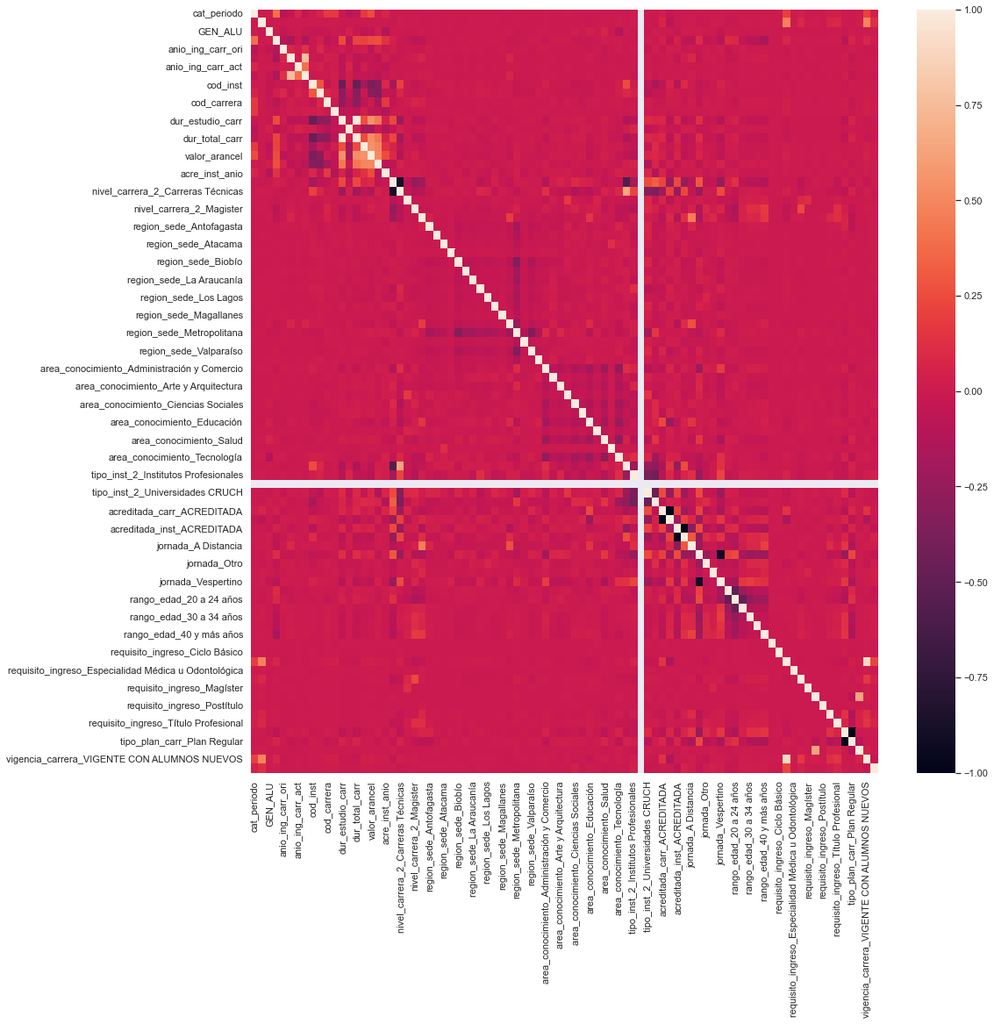

```python
import seaborn

corr_sub = df_sub_one_hot.corr()
seaborn.set(rc={'figure.figsize':(16,16)})
seaborn.heatmap(corr_sub)
```

## Comportamiento de los datos

A continuación se muestra el código para obtener los datos relacionados a la pregunta **¿Cómo se relaciona el área de conocimiento de la carrera con la edad y género de la persona que se matricula?**.

```python
# se analiza por año y luego se promedia
d = [df0, df1, df2, df3, df4, df5, df6, df7, df8, df9]
h1 = []
i = 2010

for df in d:
    dfh = (df.query("area_conocimiento!='Sin área definida'")[["GEN_ALU","rango_edad", "area_conocimiento"]]
        .groupby(by=["GEN_ALU","rango_edad", "area_conocimiento"])
        .size()
        .reset_index()
        .rename(columns = {0:'total'})
        )
    dfh["anio"] = [i]*len(dfh)
    i+=1

    h1.append(dfh.copy())

#concatenación y mapeo
dfh1 = (pd.concat(h1)[["GEN_ALU","rango_edad", "area_conocimiento", "total"]]
                 .groupby(by=["GEN_ALU","rango_edad", "area_conocimiento"])
                 .mean()
                 .reset_index()
                )
dfh1[["GEN_ALU"]] = dfh1[["GEN_ALU"]].replace({1:"Hombre", 2:"Mujer"})
dfh1 = (dfh1.replace({"SIN INFORMACION": "Sin información", "Ciencias Sociales": "C. Sociales"}))
```

El siguiente es el código utilizado para obtener los datos del gráfico que responde a la pregunta **¿Existe una correlación entre el costo de las carreras y su ubicación geográfica? ¿Varía esto a través de los años?**

```python
pd.set_option('display.float_format', lambda x: '%.2f' % x)

d = [df1, df3, df5, df7, df9]
h2 = []
i = 2011

for df in d:
    try:
        dfh = df.query("vigencia_carrera!='NO VIGENTE'")
    except:
        dfh = df
    dfh = (dfh[["codigo_unico","valor_arancel", "region_sede"]]
           .drop_duplicates()[["region_sede", "valor_arancel"]]
           .groupby(["region_sede"])
           .mean()
           .reset_index()
           .rename(columns = {"valor_arancel":'arancel_promedio_pesos'})
        )
    dfh["anio"] = [i]*len(dfh)
    i+=1
    h2.append(dfh.copy())

df_arancel_original = pd.concat(h2)

df_UF = pd.read_csv("UF.csv").rename(columns={"Periodo": "anio"})
df_UF["UF"] = df_UF["UF"].astype(float)
df_arancel_original = pd.merge(df_arancel_original, df_UF, how = "inner", on = ["anio"])
df_arancel_original["arancel_promedio_UF"] = df_arancel_original.arancel_promedio_pesos/df_arancel_original.UF
df_arancel_original = df_arancel_original[["anio", "region_sede", "arancel_promedio_UF"]].sort_values("anio", ascending = False)

df_arancel_mapeado = (df_arancel_original.replace({'Arica y Parinacota': 1, 'Tarapacá': 2, 'Antofagasta': 3, 'Atacama': 4, 'Coquimbo': 5, 'Valparaíso': 6, 'Metropolitana': 7, "Lib. Gral B. O'Higgins": 8, 'Maule': 9, 'Ñuble': 10, 'Biobío': 11, 'La Araucanía': 12, 'Los Ríos': 13, 'Los Lagos': 14, 'Aysén': 15, 'Magallanes': 16}))
df_arancel_mapeo_regiones = pd.DataFrame({"Region": ['Arica y Parinacota', 'Tarapacá', 'Antofagasta', 'Atacama', 'Coquimbo', 'Valparaíso', 'Metropolitana', "Lib. Gral B. O'Higgins", 'Maule', 'Ñuble', 'Biobío', 'La Araucanía', 'Los Ríos', 'Los Lagos', 'Aysén', 'Magallanes'], "Equivalente": list(range(1,17))})
```

## Implementación

### Pregunta 1

El analisis exploratorio para esta pregunta se encuentra acontinuación.

```python
import pandas as pd
import numpy as np
from sklearn.cluster import KMeans
from scipy.cluster.hierarchy import dendrogram, linkage
from sklearn.cluster import AgglomerativeClustering
from matplotlib import pyplot as plt
from sklearn.decomposition import PCA
from sklearn.metrics import silhouette_score

path_to_2015 = "../Data/2015.csv" # Hay que agregar el de cada uno.
df = pd.read_csv(path_to_2015) #nrows=100)
```

```python
print(df.shape)
df.iloc[10:20]
```

```
(1233043, 47)
```

|  | cat_periodo | codigo_unico | MRUN | GEN_ALU | FEC_NAC_ALU | rango_edad | anio_ing_carr_ori | sem_ing_carr_ori | anio_ing_carr_act | sem_ing_carr_act | ... | area_conocimiento | cine_f_13_area | cine_f_13_subarea | area_carrera_generica | acreditada_carr | acreditada_inst | acre_inst_desde_hasta | acre_inst_anio | costo_proceso_titulacion | costo_obtencion_titulo_diploma |
| --- | --- | --- | --- | --- | --- | --- | --- | --- | --- | --- | --- | --- | --- | --- | --- | --- | --- | --- | --- | --- | --- |
| 10 | 2015 | I16S27C27J2V1 | NaN | 2 | 198303.0 | 30 a 34 años | 9999 | 1 | 2013.0 | 1.0 | ... | Administración y Comercio | Administración de Empresas y Derecho | Educación Comercial y Administración | Ingeniería Comercial | NO ACREDITADA | NO ACREDITADA | NaN | NaN | 203500 | 305000 |
| 11 | 2015 | I16S27C27J2V1 | NaN | 2 | 198612.0 | 25 a 29 años | 9999 | 1 | 2013.0 | 1.0 | ... | Administración y Comercio | Administración de Empresas y Derecho | Educación Comercial y Administración | Ingeniería Comercial | NO ACREDITADA | NO ACREDITADA | NaN | NaN | 203500 | 305000 |
| 12 | 2015 | I16S27C27J2V1 | NaN | 1 | 198612.0 | 25 a 29 años | 9999 | 1 | 2013.0 | 1.0 | ... | Administración y Comercio | Administración de Empresas y Derecho | Educación Comercial y Administración | Ingeniería Comercial | NO ACREDITADA | NO ACREDITADA | NaN | NaN | 203500 | 305000 |
| 13 | 2015 | I16S27C27J2V1 | NaN | 2 | 198807.0 | 25 a 29 años | 9999 | 1 | 2013.0 | 1.0 | ... | Administración y Comercio | Administración de Empresas y Derecho | Educación Comercial y Administración | Ingeniería Comercial | NO ACREDITADA | NO ACREDITADA | NaN | NaN | 203500 | 305000 |
| 14 | 2015 | I16S27C27J2V1 | NaN | 2 | 198506.0 | 30 a 34 años | 9999 | 1 | 2013.0 | 1.0 | ... | Administración y Comercio | Administración de Empresas y Derecho | Educación Comercial y Administración | Ingeniería Comercial | NO ACREDITADA | NO ACREDITADA | NaN | NaN | 203500 | 305000 |
| 15 | 2015 | I16S27C27J2V1 | NaN | 1 | 198907.0 | 25 a 29 años | 9999 | 1 | 2013.0 | 1.0 | ... | Administración y Comercio | Administración de Empresas y Derecho | Educación Comercial y Administración | Ingeniería Comercial | NO ACREDITADA | NO ACREDITADA | NaN | NaN | 203500 | 305000 |
| 16 | 2015 | I16S27C27J2V1 | NaN | 2 | 198411.0 | 30 a 34 años | 9999 | 1 | 2013.0 | 1.0 | ... | Administración y Comercio | Administración de Empresas y Derecho | Educación Comercial y Administración | Ingeniería Comercial | NO ACREDITADA | NO ACREDITADA | NaN | NaN | 203500 | 305000 |
| 17 | 2015 | I16S27C27J2V1 | NaN | 2 | 198507.0 | 25 a 29 años | 9999 | 1 | 2013.0 | 1.0 | ... | Administración y Comercio | Administración de Empresas y Derecho | Educación Comercial y Administración | Ingeniería Comercial | NO ACREDITADA | NO ACREDITADA | NaN | NaN | 203500 | 305000 |
| 18 | 2015 | I16S27C27J2V1 | NaN | 2 | 197912.0 | 35 a 39 años | 9999 | 1 | 2013.0 | 1.0 | ... | Administración y Comercio | Administración de Empresas y Derecho | Educación Comercial y Administración | Ingeniería Comercial | NO ACREDITADA | NO ACREDITADA | NaN | NaN | 203500 | 305000 |
| 19 | 2015 | I16S27C27J2V1 | NaN | 1 | 196303.0 | 40 y más años | 9999 | 1 | 2013.0 | 1.0 | ... | Administración y Comercio | Administración de Empresas y Derecho | Educación Comercial y Administración | Ingeniería Comercial | NO ACREDITADA | NO ACREDITADA | NaN | NaN | 203500 | 305000 |

10 rows × 47 columns

Es necesario destacar que, a pesar de que el dataset posee abundantes atributos, como ya se dijo en el hito uno, muchos de estos pueden tienen relación directa con otros, agregado a esto, en su gran mayoria las columnas son categoricas y poseen pocas clases (o derechamente son binarias). Afortunadamente, esto se compensa con la cantidad de instancias en el dataset, del orden de millones. Con esto podemos suponer (a priori) una caracterización lo suficientemente funcional.

Seleccionamos las columnas en orden de aparición (selección para la matriz de correlación del **hito 1**):

- `rango_edad`
- `tipo_inst_2`: Clasificación del tipo de institución
- `jornada`
- `tipo_plan_carr`: Distinción dada por el tipo plan que posee la carrera o programa.
- `region_sede`: Región de la sede.
- `nivel_carrera_2`: Tipo de grado académico entregado por la carrera.
- `requisito_ingreso` *¡Eliminada, al no estar en el dataset de cada año!
- `vigencia_carrera` *¡Eliminada, al no estar en el dataset de cada año!
- `area_conocimiento`
- `acreditada_carr`: Situación de acreditación de la carrera o programa informada por la institución al 30 de abril del año del proceso.
- `acreditada_inst`: Situación acreditación de institución al 30 de abril del año en proceso.

También añadimos nuevos atributos que pueden ser vitales en la caracterización:

- `anio_ing_carr_ori`
- `sem_ing_carr_ori`
- `anio_ing_carr_act`
- `sem_ing_carr_act` (- `nomb_inst`) (- `nomb_carrera`) (- `dur_estudio_carr`) (- `dur_proceso_tit`)
- `dur_total_carr`
- `valor_matricula`
- `valor_arancel`

```python
select_columns = ["rango_edad","tipo_inst_2","jornada","tipo_plan_carr","region_sede","nivel_carrera_2","requisito_ingreso", \
    "vigencia_carrera","area_conocimiento","acreditada_carr","acreditada_inst","anio_ing_carr_ori","sem_ing_carr_ori", \
    "anio_ing_carr_act","sem_ing_carr_act",\
    "dur_total_carr", \
    "valor_matricula","valor_arancel"]
select = df.loc[:, select_columns]
# Saqué "nomb_inst", "nomb_carrera", "dur_estudio_carr","dur_proceso_tit"
```

```python
for column in select.select_dtypes('object'):
    uniques = select[column].unique()
    print(f"Valores unicos de {str(column)}: ", uniques)
```

```
Valores unicos de rango_edad:  ['20 a 24 años' '15 a 19 años' '35 a 39 años' '25 a 29 años'
 '30 a 34 años' '40 y más años' nan]
Valores unicos de tipo_inst_2:  ['Universidades Privadas' 'Universidades CRUCH' 'Institutos Profesionales'
 'Centros de Formación Técnica']
Valores unicos de jornada:  ['Diurno' 'Vespertino' 'A Distancia' 'Otro' 'Semipresencial']
Valores unicos de tipo_plan_carr:  ['Plan Regular' 'Plan Regular de Continuidad' 'Plan Especial']
Valores unicos de region_sede:  ['Metropolitana' 'Coquimbo' 'Tarapacá' 'Arica y Parinacota' 'Valparaíso'
 'Ñuble' 'Antofagasta' 'Atacama' 'Biobío' "Lib. Gral B. O'Higgins"
 'La Araucanía' 'Maule' 'Los Lagos' 'Magallanes' 'Los Ríos' 'Aysén']
Valores unicos de nivel_carrera_2:  ['Carreras Profesionales' 'Carreras Técnicas' 'Magister' 'Postítulo'
 'Doctorado']
Valores unicos de requisito_ingreso:  ['Educación Media' 'Licenciatura' nan 'Título Profesional'
 'Técnico de Nivel Superior' 'Magíster'
 'Especialidad Médica u Odontológica' 'Plan Común' 'Ciclo Básico'
 'Postítulo' 'Bachillerato']
Valores unicos de vigencia_carrera:  ['VIGENTE CON ALUMNOS NUEVOS' 'VIGENTE SIN ALUMNOS NUEVOS']
Valores unicos de area_conocimiento:  ['Ciencias Sociales' 'Administración y Comercio' 'Arte y Arquitectura'
 'Tecnología' 'Salud' 'Ciencias Básicas' 'Agropecuaria' 'Educación'
 'Humanidades' 'Derecho' 'Sin área definida']
Valores unicos de acreditada_carr:  ['NO ACREDITADA' 'ACREDITADA']
Valores unicos de acreditada_inst:  ['ACREDITADA' 'NO ACREDITADA']
```

Ordinales:

- rango_edad {'15 a 19 años':1,'20 a 24 años':2, '35 a 39 años':3, '25 a 29 años':4, '30 a 34 años':5, '40 y más años':6}
- nivel_carrera_2 {'Carreras Técnicas':1, 'Carreras Profesionales':2, 'Magister':3, 'Postítulo':4, 'Doctorado':5}
- acreditada_carr {"NO ACREDITADA":0, "ACREDITADA":1}
- acreditada_inst {"NO ACREDITADA":0, "ACREDITADA":1}

Se creará un diccionario para cada atributo, con sus clases y codificaciones.

```python
all_dict = {}
for column in select.select_dtypes('object'):
    all_dict[column] = {value:i+1 for i, value in enumerate(select[column].unique()) if value is not np.nan}

print(all_dict)
all_dict["rango_edad"] = {'15 a 19 años':1,'20 a 24 años':2, '35 a 39 años':3, '25 a 29 años':4, '30 a 34 años':5, '40 y más años':6}
all_dict["nivel_carrera_2"] = {'Carreras Técnicas':1, 'Carreras Profesionales':2, 'Magister':3, 'Postítulo':4, 'Doctorado':5}
all_dict["acreditada_carr"] = {"NO ACREDITADA":0, "ACREDITADA":1}
all_dict["acreditada_inst"] = {"NO ACREDITADA":0, "ACREDITADA":1}
```

```
{'rango_edad': {'20 a 24 años': 1, '15 a 19 años': 2, '35 a 39 años': 3, '25 a 29 años': 4, '30 a 34 años': 5, '40 y más años': 6}, 'tipo_inst_2': {'Universidades Privadas': 1, 'Universidades CRUCH': 2, 'Institutos Profesionales': 3, 'Centros de Formación Técnica': 4}, 'jornada': {'Diurno': 1, 'Vesp…
```

```python
for attribute in all_dict:
    select[attribute] = select[attribute].map(all_dict[attribute])
select
```

|  | rango_edad | tipo_inst_2 | jornada | tipo_plan_carr | region_sede | nivel_carrera_2 | requisito_ingreso | vigencia_carrera | area_conocimiento | acreditada_carr | acreditada_inst | anio_ing_carr_ori | sem_ing_carr_ori | anio_ing_carr_act | sem_ing_carr_act | dur_total_carr | valor_matricula | valor_arancel |
| --- | --- | --- | --- | --- | --- | --- | --- | --- | --- | --- | --- | --- | --- | --- | --- | --- | --- | --- |
| 0 | 2.0 | 1 | 1 | 1 | 1 | 2 | 1.0 | 1 | 1 | 0 | 1 | 2015 | 1 | NaN | NaN | 8 | 100000.0 | 3369000.0 |
| 1 | 1.0 | 1 | 2 | 1 | 1 | 2 | 1.0 | 1 | 2 | 1 | 1 | 2015 | 1 | NaN | NaN | 8 | 100000.0 | 2312000.0 |
| 2 | 2.0 | 1 | 1 | 1 | 2 | 2 | 1.0 | 1 | 1 | 0 | 0 | 2015 | 1 | NaN | NaN | 10 | 120000.0 | 2185000.0 |
| 3 | 3.0 | 1 | 2 | 1 | 2 | 2 | 1.0 | 1 | 2 | 0 | 0 | 2015 | 1 | NaN | NaN | 10 | 120000.0 | 1760000.0 |
| 4 | 2.0 | 1 | 1 | 1 | 1 | 2 | 1.0 | 1 | 3 | 0 | 1 | 2015 | 1 | NaN | NaN | 10 | 363900.0 | 3900530.0 |
| ... | ... | ... | ... | ... | ... | ... | ... | ... | ... | ... | ... | ... | ... | ... | ... | ... | ... | ... |
| 1233038 | 6.0 | 1 | 5 | 1 | 1 | 4 | 4.0 | 2 | 10 | 0 | 1 | 2014 | 1 | NaN | NaN | 1 | 0.0 | 1327500.0 |
| 1233039 | 1.0 | 3 | 2 | 1 | 1 | 1 | 1.0 | 1 | 5 | 0 | 1 | 2015 | 1 | NaN | NaN | 7 | 89900.0 | 1489900.0 |
| 1233040 | 1.0 | 1 | 1 | 1 | 1 | 2 | 1.0 | 1 | 4 | 0 | 1 | 2015 | 1 | NaN | NaN | 10 | 340000.0 | 3590000.0 |
| 1233041 | 3.0 | 2 | 1 | 3 | 3 | 3 | 4.0 | 2 | 6 | 0 | 1 | 2013 | 1 | NaN | NaN | 6 | 150000.0 | 1166666.0 |
| 1233042 | 1.0 | 2 | 1 | 1 | 7 | 2 | 1.0 | 1 | 3 | 0 | 1 | 9998 | 1 | 2014.0 | 1.0 | 12 | 122000.0 | 3209000.0 |

1233043 rows × 18 columns

```python
select.iloc[:,:-2] = select.iloc[:,:-2].convert_dtypes(np.int32)
dummies = pd.get_dummies(select, prefix=select_columns[:-2], columns=select_columns[:-2])
dummies
```

|  | valor_matricula | valor_arancel | rango_edad_1 | rango_edad_2 | rango_edad_3 | rango_edad_4 | rango_edad_5 | rango_edad_6 | tipo_inst_2_1 | tipo_inst_2_2 | ... | dur_total_carr_8 | dur_total_carr_9 | dur_total_carr_10 | dur_total_carr_11 | dur_total_carr_12 | dur_total_carr_13 | dur_total_carr_14 | dur_total_carr_16 | dur_total_carr_20 | dur_total_carr_24 |
| --- | --- | --- | --- | --- | --- | --- | --- | --- | --- | --- | --- | --- | --- | --- | --- | --- | --- | --- | --- | --- | --- |
| 0 | 100000.0 | 3369000.0 | 0 | 1 | 0 | 0 | 0 | 0 | 1 | 0 | ... | 1 | 0 | 0 | 0 | 0 | 0 | 0 | 0 | 0 | 0 |
| 1 | 100000.0 | 2312000.0 | 1 | 0 | 0 | 0 | 0 | 0 | 1 | 0 | ... | 1 | 0 | 0 | 0 | 0 | 0 | 0 | 0 | 0 | 0 |
| 2 | 120000.0 | 2185000.0 | 0 | 1 | 0 | 0 | 0 | 0 | 1 | 0 | ... | 0 | 0 | 1 | 0 | 0 | 0 | 0 | 0 | 0 | 0 |
| 3 | 120000.0 | 1760000.0 | 0 | 0 | 1 | 0 | 0 | 0 | 1 | 0 | ... | 0 | 0 | 1 | 0 | 0 | 0 | 0 | 0 | 0 | 0 |
| 4 | 363900.0 | 3900530.0 | 0 | 1 | 0 | 0 | 0 | 0 | 1 | 0 | ... | 0 | 0 | 1 | 0 | 0 | 0 | 0 | 0 | 0 | 0 |
| ... | ... | ... | ... | ... | ... | ... | ... | ... | ... | ... | ... | ... | ... | ... | ... | ... | ... | ... | ... | ... | ... |
| 1233038 | 0.0 | 1327500.0 | 0 | 0 | 0 | 0 | 0 | 1 | 1 | 0 | ... | 0 | 0 | 0 | 0 | 0 | 0 | 0 | 0 | 0 | 0 |
| 1233039 | 89900.0 | 1489900.0 | 1 | 0 | 0 | 0 | 0 | 0 | 0 | 0 | ... | 0 | 0 | 0 | 0 | 0 | 0 | 0 | 0 | 0 | 0 |
| 1233040 | 340000.0 | 3590000.0 | 1 | 0 | 0 | 0 | 0 | 0 | 1 | 0 | ... | 0 | 0 | 1 | 0 | 0 | 0 | 0 | 0 | 0 | 0 |
| 1233041 | 150000.0 | 1166666.0 | 0 | 0 | 1 | 0 | 0 | 0 | 0 | 1 | ... | 0 | 0 | 0 | 0 | 0 | 0 | 0 | 0 | 0 | 0 |
| 1233042 | 122000.0 | 3209000.0 | 1 | 0 | 0 | 0 | 0 | 0 | 0 | 1 | ... | 0 | 0 | 0 | 0 | 1 | 0 | 0 | 0 | 0 | 0 |

1233043 rows × 159 columns

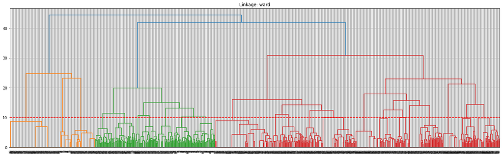

[figure not shown]

```python
height = 10
ward = linkage(dummies.iloc[:1000,2:], method="ward")
fig, ax = plt.subplots(1, 1, figsize=(24,7))
dendrogram(ward, ax=ax)
plt.grid()
plt.title("Linkage: ward")
plt.axhline(y=height, color='r', linestyle='--')
plt.show()

complete = linkage(dummies.iloc[:1000,2:], method="complete")
fig, ax = plt.subplots(1, 1, figsize=(24,7))
dendrogram(complete, ax=ax)
plt.grid()
plt.title("Linkage: ward")
plt.axhline(y=4, color='r', linestyle='--')
plt.show()
```

```python
used = 10000 # len(dummies)
```

Podemos reconocer una leve estructura de cluster en los datos, para el espacio One-Hot. En el caso del método PCA aplicado al espacio antes mencionado, notamos solapamiento entre clusters, aún así, en el gráfico podemos apreciacar estructuras interantes, las que posiblemente contengas información relevante.

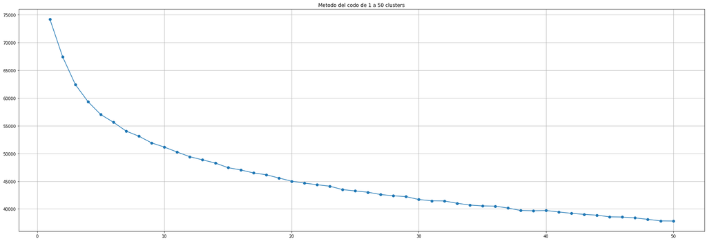

```python
sse_k = []
sse_w = []
total_ = 50
clusters = list(range(1, total_+1))
for k in clusters:
    kmeans = KMeans(n_clusters=k).fit(dummies.iloc[:used,2:])
    #wards = AgglomerativeClustering(n_clusters=k, linkage="ward").fit(dummies.iloc[:used,2:])
    sse_k.append(kmeans.inertia_)
    #sse_w.append(wards.affinity)

fig, ax = plt.subplots(1,1, figsize=(30,10))
ax.plot(clusters, sse_k, "o-")
plt.title(f"Metodo del codo de 1 a {total_} clusters")
plt.grid(True)
plt.show()
```

```
20
```

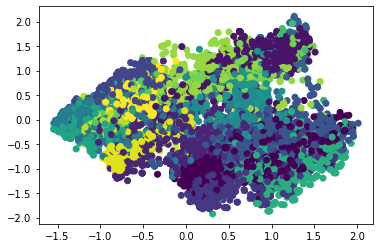

```
Silhouete del espacio PCA con Clusterning Jerarquico (ward)	 -0.05801003812797862
Silhouette del espacio one-hot con Clusterning Jerarquico (ward)	 0.05964943994947762
```

```python
n_clus = 20
ward = AgglomerativeClustering(n_clusters=n_clus, linkage="ward", distance_threshold=None).fit(dummies.iloc[:used,2:])
print(ward.n_clusters_)

new_space = PCA(n_components=2, random_state=1).fit_transform(dummies.iloc[:used,2:])

plt.scatter(new_space[:, 0], new_space[:, 1], c=ward.labels_)
plt.show()

print("Silhouete del espacio PCA con Clusterning Jerarquico (ward)\t", silhouette_score(new_space, ward.labels_))
print("Silhouette del espacio one-hot con Clusterning Jerarquico (ward)\t", silhouette_score(dummies.iloc[:used,2:], ward.labels_))
```

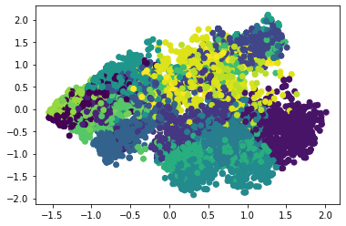

```
Silhouete del espacio PCA con KMeans Clustering	 0.023934520346331697
Silhouete del espacio One-hot con KMeans Clustering	 0.09104361600059412
```

```python
from sklearn.cluster import KMeans

kmean = KMeans(n_clusters=n_clus).fit(dummies.iloc[:used,2:])

new_space = PCA(n_components=2, random_state=1).fit_transform(dummies.iloc[:used,2:])

plt.scatter(new_space[:, 0], new_space[:, 1], c=kmean.labels_)
plt.show()

print("Silhouete del espacio PCA con KMeans Clustering\t", silhouette_score(new_space, kmean.labels_))
print("Silhouete del espacio One-hot con KMeans Clustering\t", silhouette_score(dummies.iloc[:used,2:], kmean.labels_))
```

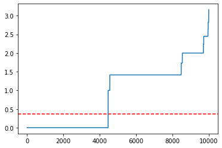

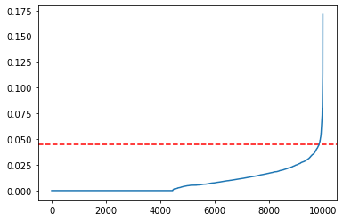

```python
from sklearn.neighbors import NearestNeighbors
import numpy as np

nbrs = NearestNeighbors(n_neighbors=3).fit(dummies.iloc[:used,2:])
distances, indices = nbrs.kneighbors(dummies.iloc[:used,2:])

y_ = 0.37
distances = np.sort(distances, axis=0)
distances = distances[:,1]
plt.axhline(y=y_, color='r', linestyle='--') #Ajuste el valor para "y" en esta línea
plt.plot(distances)
plt.show()

new_space = PCA(n_components=2, random_state=1).fit_transform(dummies.iloc[:used,2:])
nbrs = NearestNeighbors(n_neighbors=3).fit(new_space)
distances, indices = nbrs.kneighbors(new_space)

y_ = 0.045
distances = np.sort(distances, axis=0)
distances = distances[:,1]
plt.axhline(y=y_, color='r', linestyle='--') #Ajuste el valor para "y" en esta línea
plt.plot(distances)
plt.show()
```

Imposible establecer mediante el "método de la rodilla" un valor óptimo para epsilon. Esto de igual forma podría indicar que no se establecen cluster de la forma en que DBSCAN los establece.

El segundo gráfico es no concluyente, al aplicarse a una colección de vectores productos del PCA.

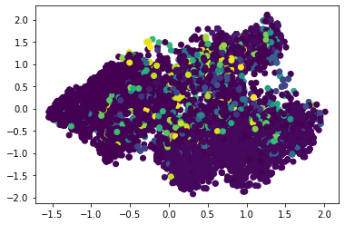

```
Silhouete del espacio PCA con DBSCAN Clustering	 -0.7288990506788339
Silhouete del espacio One-hot con DBSCAN Clustering	 -0.13678011620936573
```

```python
from sklearn.cluster import DBSCAN
dbscan = DBSCAN(eps=1.5, min_samples=2).fit(dummies.iloc[:used,2:])

new_space = PCA(n_components=2, random_state=1).fit_transform(dummies.iloc[:used,2:])

plt.scatter(new_space[:, 0], new_space[:, 1], c=dbscan.labels_)
plt.show()

print("Silhouete del espacio PCA con DBSCAN Clustering\t", silhouette_score(new_space, dbscan.labels_))
print("Silhouete del espacio One-hot con DBSCAN Clustering\t", silhouette_score(dummies.iloc[:used,2:], dbscan.labels_))
```

DBSCAN no es el método de clustering indicado para el problema

```python
import pandas as pd
import numpy as np
from sklearn.cluster import KMeans
from matplotlib import pyplot as plt
from sklearn.decomposition import PCA
from sklearn.metrics import silhouette_score
from sklearn.metrics.pairwise import euclidean_distances
```

```python
s_columns = ["rango_edad","tipo_inst_2","jornada","tipo_plan_carr","region_sede","nivel_carrera_2","requisito_ingreso", \
    "vigencia_carrera","area_conocimiento","acreditada_carr","acreditada_inst","anio_ing_carr_ori","sem_ing_carr_ori", \
    "anio_ing_carr_act","sem_ing_carr_act",\
    "dur_total_carr", \
    "valor_matricula","valor_arancel"]
# Saqué "nomb_inst", "nomb_carrera", "dur_estudio_carr","dur_proceso_tit"

path_to_2015 = "../../Data/2015.csv" # Hay que agregar el de cada uno.
df = pd.read_csv(path_to_2015)
select = df.loc[:, s_columns]
all_dict = {}
for column in select.select_dtypes('object'):
    all_dict[column] = {value:i+1 for i, value in enumerate(select[column].unique()) if value is not np.nan}

print(all_dict)
all_dict["rango_edad"] = {'15 a 19 años':1,'20 a 24 años':2, '35 a 39 años':3, '25 a 29 años':4, '30 a 34 años':5, '40 y más años':6}
all_dict["nivel_carrera_2"] = {'Carreras Técnicas':1, 'Carreras Profesionales':2, 'Magister':3, 'Postítulo':4, 'Doctorado':5}
all_dict["acreditada_carr"] = {"NO ACREDITADA":0, "ACREDITADA":1}
all_dict["acreditada_inst"] = {"NO ACREDITADA":0, "ACREDITADA":1}
```

```
{'rango_edad': {'20 a 24 años': 1, '15 a 19 años': 2, '35 a 39 años': 3, '25 a 29 años': 4, '30 a 34 años': 5, '40 y más años': 6}, 'tipo_inst_2': {'Universidades Privadas': 1, 'Universidades CRUCH': 2, 'Institutos Profesionales': 3, 'Centros de Formación Técnica': 4}, 'jornada': {'Diurno': 1, 'Vesp…
```

```python
def sim_matrix(features, labels):
    useful_labels = labels >= 0

    # primero ordenamos los datos en base al cluster que pertencen
    indices = np.argsort(labels[useful_labels])
    sorted_features = features[useful_labels][indices]

    # calculamos las distancias entre todos los puntos
    d = euclidean_distances(sorted_features, sorted_features)
    return d

def plotproxi(data, model):
    fig, (ax1, ax2) = plt.subplots(1, 2, figsize=(20,5))

    fig.suptitle(f"{model.__class__.__name__}")

    ax1.scatter(data[:,0], data[:,1], c=model.labels_)

    dist = sim_matrix(data, model.labels_)
    im = ax2.imshow(dist, cmap="jet")
    fig.colorbar(im, ax=ax2)

# Podemos seleccionar un atributo, y ordenar los clusters de acuerdo
# a la cantidad de cierta caracteristica en el atributo.
def right_tag(df, model,  n_clusters, col="area_conocimiento", value="Ciencias Básicas"):
    indx = all_dict[col][value]
    quantities = np.zeros(n_clusters)
    for cluster in range(n_clusters):
        count = df.loc[model.labels_==cluster,:][col].value_counts()
        try: val = count.loc[indx]
        except: val = 0
        quantities[cluster] = val
    neworder = np.argsort(quantities)
    model.labels_ = np.array([neworder[label] for label in model.labels_])
    #return
```

```python
used = 10000
n_clus = 20 # Ideal: 20
np.random.seed(10)
n_years = 10
ndims = 2

select_columns = s_columns.copy()
for nn in ['requisito_ingreso', 'vigencia_carrera']:
    try: select_columns.remove(nn)
    except: pass
    try: all_dict.pop(nn)
    except: pass

macro_varancel = np.zeros(n_years)
macro_vmatricula = np.zeros(n_years)
macro_areaconocimiento = np.zeros(n_years, dtype='object')
macro_acredcarr = np.zeros(n_years, dtype='object')

centroid_coord = np.zeros((n_years, n_clus, ndims))
for i in range(n_years):
    path = f"../../Data/201{i}.csv" # Hay que agregar el de cada uno.
    df = pd.read_csv(path, nrows=None)
    sample = np.random.choice(len(df), used)

    macro_varancel[i] = df["valor_arancel"].mean()
    macro_vmatricula[i] = df["valor_matricula"].mean()
    macro_acredcarr[i] = df["acreditada_carr"].value_counts().index[0]
    macro_areaconocimiento[i] = df["area_conocimiento"].value_counts().index[0]

    #Se escoger al azar 'used' número de instancias.
    df = df.loc[sample, select_columns]
    for attribute in all_dict:
        df[attribute] = df[attribute].map(all_dict[attribute])
    df.iloc[:,:-2] = df.iloc[:,:-2].convert_dtypes(np.int32)
    dumm = pd.get_dummies(df, prefix=select_columns[:-2], columns=select_columns[:-2])

    print("n° de instancias: ", len(df))

    kmean = KMeans(n_clusters=n_clus).fit(dumm.iloc[:,2:])
    print(f"Inercia del año 201{i}", kmean.inertia_)
    right_tag(df,kmean,n_clus) # Nuevas labels por contenido.

    pca = PCA(n_components=ndims, random_state=1).fit(dumm.iloc[:,2:])
    new_space = pca.transform(dumm.iloc[:,2:])
    plotproxi(new_space, kmean)
    plt.show()
    centroid_coord[i, :, :] = pca.transform(kmean.cluster_centers_)

    print("n° de instancias usadas: ", used)
    print("Silhouete del espacio PCA con KMeans Clustering\t", silhouette_score(new_space, kmean.labels_))
    print("Silhouette del espacio one-hot con KMeans Clustering\t", silhouette_score(dumm.iloc[:,2:], kmean.labels_))
    print()

for centroid in range(n_clus):
    a = centroid_coord[:-1,centroid,:]
    print(a[:,0])
    b = centroid_coord[1:,centroid,:]
    fig, ax = plt.subplots(1, 1, figsize=(10,5))
    ax.set_xlim(-1.5,1.5)
    ax.set_ylim(-1.5,1.5)
    ax.quiver(a[:,0], a[:,1], b[:,0]-a[:,0], b[:,1]-a[:,1], scale_units='xy', angles='xy', scale=1)
    plt.show()
```

### Pregunta 2

El código utilizado para generar el Heatmap se muestra a continuación:

```python
# Se obtienen los tipos de cada columa en un dataframe
sub_df_0to7_datatypes = (pd.DataFrame(sub_df_0to7.dtypes)
                    .reset_index()
                    .rename(columns = {0:'tipo', 'index' : 'columna'})
                    )

# para cada columna...
cols_name = list(sub_df_0to7).remove('GEN_ALU')
df_sub_one_hot = pd.get_dummies(sub_df_0to7[['GEN_ALU']], prefix='GEN_ALU')
for i in range(1, len(sub_df_0to7_datatypes)):
    col_name = sub_df_0to7_datatypes.iloc[i][0]

    # Si es que es de tipo object...
    if str(sub_df_0to7_datatypes.iloc[i][1]) == 'object':
        # se le aplica la transformación One Hot
        df_one_hot = pd.get_dummies(sub_df_0to7[[col_name]], prefix=col_name)
    else:
        df_one_hot = sub_df_0to7[[col_name]]
    df_sub_one_hot = pd.merge(df_sub_one_hot, df_one_hot, left_index=True, right_index=True)

df_sub_one_hot = df_sub_one_hot.reset_index(drop=True)
```

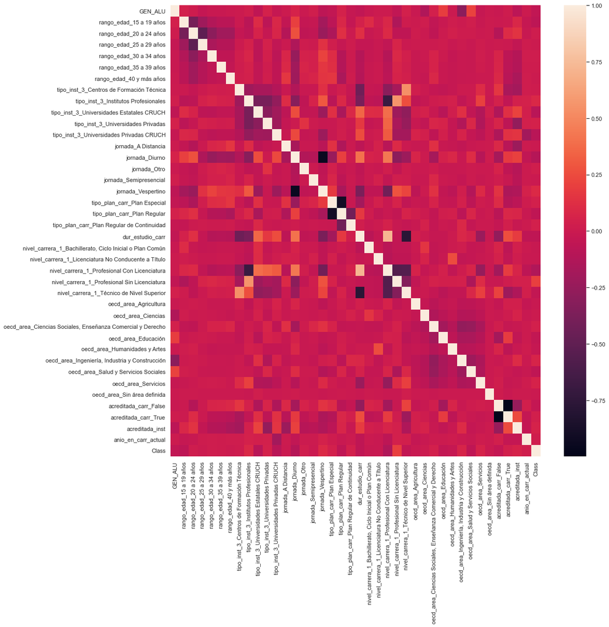

```python
import seaborn

# Se aplica One Hot
corr_sub = df_sub_one_hot.corr()
seaborn.set(rc={'figure.figsize':(16,16)})
seaborn.heatmap(corr_sub)
```

Las funciones `train(Classifier, data_dict)` y `get_data_dict(df, testSize)` se muestran a continuación

```python
from sklearn.metrics import f1_score, recall_score, precision_score
from sklearn.model_selection import train_test_split

def get_data_dict(df, testSize):
    data_train, data_test, ytrain, ytest = train_test_split(df, df['Class'], test_size=testSize, stratify=df['Class'])
    diferencia = ytrain.value_counts()[False]-ytrain.value_counts()[True]
    data_train = data_train.reset_index(drop=True)

    # oversampling sobre la clase True
    idx = np.random.choice(data_train[data_train['Class'] == True].index, size=diferencia)
    data_oversampled = pd.concat([data_train, data_train.iloc[idx]])
    print("Data oversampled on class 'True'")
    print(data_oversampled['Class'].value_counts())

    # subsampling sobre la clase False
    idx = np.random.choice(data_train.loc[data_train.Class == False].index, size=diferencia, replace=False)
    data_subsampled = data_train.drop(data_train.iloc[idx].index)
    print("Data subsampled on class 'False'")
    print(data_subsampled['Class'].value_counts())

    # Se definen los conjuntos de testeo
    X_test = data_test[data_train.columns[:-1]]
    y_test = data_test[data_train.columns[-1]]

    # datos entrenamiento "originales"
    X_orig = data_train[data_train.columns[:-1]]
    y_orig = data_train[data_train.columns[-1]]

    # datos entrenamiento "oversampleados"
    X_over = data_oversampled[data_train.columns[:-1]]
    y_over = data_oversampled[data_train.columns[-1]]

    # datos entrenamiento "subsampleados"
    X_subs = data_subsampled[data_train.columns[:-1]]
    y_subs = data_subsampled[data_train.columns[-1]]

    return {'X_test': X_test, 'y_test': y_test, 'X_orig': X_orig, 'y_orig': y_orig, 'X_over': X_over, 'y_over': y_over, 'X_subs': X_subs, 'y_subs': y_subs}
```

```python
from sklearn.metrics import classification_report

def train(Classifier, data_dict):
    print("::::::::::Datos originales")
    clf_orig = Classifier()
    clf_orig.fit(data_dict['X_orig'], data_dict['y_orig'])
    pred_orig = clf_orig.predict(data_dict['X_test'])
    print(classification_report(data_dict['y_test'], pred_orig))

    print("::::::::::Datos con oversampling")
    clf_over = Classifier()
    clf_over.fit(data_dict['X_over'], data_dict['y_over'])
    pred_over = clf_over.predict(data_dict['X_test'])
    print(classification_report(data_dict['y_test'], pred_over))

    print("::::::::::Datos con subsampling")
    clf_subs = Classifier()
    clf_subs.fit(data_dict['X_subs'], data_dict['y_subs'])
    pred_subs = clf_subs.predict(data_dict['X_test'])
    print(classification_report(data_dict['y_test'], pred_subs))

    return clf_orig, clf_over, clf_subs
```

Para entrenar cada modelo y ver sus métricas se hizo como sigue;

```python
data_dict = get_data_dict(df_sub_one_hot, testSize = 0.995)
```

```
Data oversampled on class 'True'
True     9205
False    9205
Name: Class, dtype: int64
Data subsampled on class 'False'
True     955
False    955
Name: Class, dtype: int64
```

```python
from sklearn.tree import DecisionTreeClassifier

print("Resultados para Árbol de Decisión")
DTC_orig, DTC_over, DTC_subs = train(DecisionTreeClassifier, data_dict)
```

```
Resultados para Árbol de Decisión
::::::::::Datos originales
              precision    recall  f1-score   support

       False       0.97      0.98      0.97   1831973
        True       0.76      0.68      0.72    190001

    accuracy                           0.95   2021974
   macro avg       0.86      0.83      0.84   2021974
weighted avg       0.95      0.95      0.95   2021974

::::::::::Datos con oversampling
              precision    recall  f1-score   support

       False       0.98      0.95      0.96   1831973
        True       0.60      0.77      0.68    190001

    accuracy                           0.93   2021974
   macro avg       0.79      0.86      0.82   2021974
weighted avg       0.94      0.93      0.93   2021974

::::::::::Datos con subsampling
              precision    recall  f1-score   support

       False       0.99      0.90      0.94   1831973
        True       0.47      0.88      0.61    190001

    accuracy                           0.89   2021974
   macro avg       0.73      0.89      0.78   2021974
weighted avg       0.94      0.89      0.91   2021974
```

```python
from sklearn.naive_bayes import GaussianNB  # Naive bayes

print("Resultados para Naive bayes")
NB_orig, NB_over, NB_subs = train(GaussianNB, data_dict)
```

```
Resultados para Naive bayes
::::::::::Datos originales
              precision    recall  f1-score   support

       False       0.99      0.80      0.89   1831973
        True       0.33      0.93      0.48    190001

    accuracy                           0.81   2021974
   macro avg       0.66      0.87      0.69   2021974
weighted avg       0.93      0.81      0.85   2021974

::::::::::Datos con oversampling
              precision    recall  f1-score   support

       False       0.99      0.79      0.88   1831973
        True       0.32      0.96      0.48    190001

    accuracy                           0.80   2021974
   macro avg       0.66      0.87      0.68   2021974
weighted avg       0.93      0.80      0.84   2021974

::::::::::Datos con subsampling
              precision    recall  f1-score   support

       False       1.00      0.79      0.88   1831973
        True       0.32      0.96      0.48    190001

    accuracy                           0.81   2021974
   macro avg       0.66      0.88      0.68   2021974
weighted avg       0.93      0.81      0.84   2021974
```

```python
from sklearn.neighbors import KNeighborsClassifier

print("Resultados para K Neighbors")
KNN_orig, KNN_over, KNN_subs = train(KNeighborsClassifier, data_dict)
```

```
Resultados para K Neighbors
::::::::::Datos originales
              precision    recall  f1-score   support

       False       0.96      0.98      0.97   1831973
        True       0.74      0.59      0.65    190001

    accuracy                           0.94   2021974
   macro avg       0.85      0.78      0.81   2021974
weighted avg       0.94      0.94      0.94   2021974

::::::::::Datos con oversampling
              precision    recall  f1-score   support

       False       0.98      0.89      0.93   1831973
        True       0.45      0.86      0.59    190001

    accuracy                           0.89   2021974
   macro avg       0.72      0.87      0.76   2021974
weighted avg       0.93      0.89      0.90   2021974

::::::::::Datos con subsampling
              precision    recall  f1-score   support

       False       0.99      0.80      0.88   1831973
        True       0.32      0.92      0.47    190001

    accuracy                           0.81   2021974
   macro avg       0.65      0.86      0.68   2021974
weighted avg       0.93      0.81      0.85   2021974
```

```python
from sklearn.svm import SVC  # Support Vector Machine classifier

print("Resultados para Support Vector Machine")
SVM_orig, SVM_over, SVM_subs = train(SVC, data_dict)
```

```
Resultados para Support Vector Machine
::::::::::Datos originales
```

[output not shown]

Para entrenar los clasificadores *Árbol de Decisión* y *Naive bayes* con el $70\%$ de los datos se utilizó el siguiente código:

```python
data_dict = get_data_dict(df_sub_one_hot, testSize = 0.3)
```

```
Data oversampled on class 'True'
True     1288824
False    1288824
Name: Class, dtype: int64
Data subsampled on class 'False'
True     133669
False    133669
Name: Class, dtype: int64
```

```python
print("Resultados para Árbol de Decisión")
DTC_orig, DTC_over, DTC_subs = train(DecisionTreeClassifier, data_dict)
```

```
Resultados para Árbol de Decisión
::::::::::Datos originales
              precision    recall  f1-score   support

       False       0.97      0.99      0.98    552354
        True       0.85      0.75      0.80     57287

    accuracy                           0.96    609641
   macro avg       0.91      0.87      0.89    609641
weighted avg       0.96      0.96      0.96    609641

::::::::::Datos con oversampling
              precision    recall  f1-score   support

       False       0.99      0.92      0.96    552354
        True       0.55      0.95      0.70     57287

    accuracy                           0.92    609641
   macro avg       0.77      0.94      0.83    609641
weighted avg       0.95      0.92      0.93    609641

::::::::::Datos con subsampling
              precision    recall  f1-score   support

       False       0.99      0.92      0.96    552354
        True       0.55      0.95      0.70     57287

    accuracy                           0.92    609641
   macro avg       0.77      0.93      0.83    609641
weighted avg       0.95      0.92      0.93    609641
```

```python
print("Resultados para Naive bayes")
NB_orig, NB_over, NB_subs = train(GaussianNB, data_dict)
```

```
Resultados para Naive bayes
::::::::::Datos originales
              precision    recall  f1-score   support

       False       0.99      0.80      0.89    552354
        True       0.33      0.95      0.49     57287

    accuracy                           0.81    609641
   macro avg       0.66      0.87      0.69    609641
weighted avg       0.93      0.81      0.85    609641

::::::::::Datos con oversampling
              precision    recall  f1-score   support

       False       0.99      0.79      0.88    552354
        True       0.32      0.96      0.48     57287

    accuracy                           0.80    609641
   macro avg       0.66      0.87      0.68    609641
weighted avg       0.93      0.80      0.84    609641

::::::::::Datos con subsampling
              precision    recall  f1-score   support

       False       0.99      0.79      0.88    552354
        True       0.32      0.96      0.48     57287

    accuracy                           0.80    609641
   macro avg       0.66      0.87      0.68    609641
weighted avg       0.93      0.80      0.84    609641
```

### Pregunta 3

```python
def seleccionar_cols(filename ,anio ,cols):
      df = pd.read_csv(filename, error_bad_lines=False)
      df_filtered = df[cols]
      name = f'data_acre/data_acre_{anio}'
      df_filtered.to_csv(name+'.csv',index=False)
      return df_filtered


  def modificar_cols(filename , anio):
      df = pd.read_csv(filename, error_bad_lines=False)
      #df = df.iloc[:20]
      ###############
      # numericas
      ###############
      #modificar genero
      df['GEN_ALU'] = df['GEN_ALU'].replace(to_replace = {1:'masculino' ,
                                                          2:'femenino'})
      #cambiar anios de acreditacion
      df['acre_inst_anio'] = df['acre_inst_anio'].fillna(0)

      #fecha de nacimiento
      df = df.dropna()
      df.index = np.arange(len(df))
      nac = pd.Series(data=np.arange(len(df)), index=np.arange(len(df)))
      ing = pd.Series(data=np.arange(len(df)), index=np.arange(len(df)))
      for i in range(len(df)):
          fecha_nac = str(int(df.iloc[i]['FEC_NAC_ALU']))
          fecha_ingreso = int(df.iloc[i]['anio_ing_carr_ori'])
          today = date(anio, 2, 1)
          nac.iloc[i] = int((today - date(int(fecha_nac[:4]), int(fecha_nac[4:]), 1)).days/365)
          ing.iloc[i] = int((today - date(fecha_ingreso, 1, 1)).days/365)
      df['edad_alu']  = nac
      df['anios_U']   = ing
      df = df.loc[df['edad_alu']>=0]
      df = df.loc[df['anios_U']>=0]
      df['dur_total_carr'] = df['dur_total_carr'] / 2

      cols_filter = ['tipo_inst_2','region_sede','nivel_carrera_2','cine_f_13_area','GEN_ALU',
                     'acreditada_carr','dur_total_carr','valor_arancel','edad_alu','acre_inst_anio','anios_U']


      name = f'data_acre/modif_acre_{anio}'
      df[cols_filter].to_csv(name+'.csv',index=False)
```

```python
def histogramasCategoricas(df,anio):
      fig, axs = plt.subplots(nrows=1 ,ncols=5 ,figsize = (17,5.5))
      axs = axs.flatten()
      cols = df.columns.values
      count = 0
      total = len(df)
      cols_info = {'tipo_inst_2':('Tipo de Institución',(0,0.27)),
                   'region_sede':('Region de la sede',(0,0.35)),
                   'nivel_carrera_2': (' Tipo de carrera',(0,0.5)),
                   'cine_f_13_area':('Área de la carrera',(0,0.25)),
                   'GEN_ALU':('Genero de alumno',(0,0.4))}

      for i,col in enumerate(cols_info):
          title, ylim = cols_info[col]
          w = 0.45
          ax = axs[i]
          acre = (df['acreditada_carr'] == 'ACREDITADA')
          ndf = df[col]
          si_acre = ndf[acre]
          no_acre = ndf[acre==False]
          ass = si_acre.value_counts()
          an = no_acre.value_counts()
          bs = np.sort(ass.index.values)
          bn = np.sort(an.index.values)
          x = np.arange(len(bn))
          ax.bar(x-0.23,an[bs]/total,width= w,color='red',alpha = 0.5,label = 'Carrera no acreditada')
          ax.bar(x+0.23,ass[bs]/total,width= w,color='blue',alpha = 0.5,label = 'Carrera acreditada')
          ax.set_title(title)
          ax.grid(axis = 'both' ,color='gray', linestyle='--', linewidth=0.6)
          ax.xaxis.set_ticks(x)

          ax.set_xlim((-0.5,x[-1]+0.5))
          ax.set_ylim(ylim)
          if col == 'cine_f_13_area':
              bn = ['Administración y Derecho','Agricultura y Veterinaria',
                    'Artes y Humanidades', 'Ciencias Sociales','Ciencias',
                    'Educación','Ingeniería','Salud y Bienestar',
                    'Servicios','TIC']
              ax.legend()
          #ax.xaxis.set_ticks(bn)
          ax.set_xticklabels(bn, rotation=90)
      plt.show(block=False)
      fig.tight_layout()
      #plt.savefig(f'{anio}_Cat.png', format="png")

  def histogramasNumericas(df,anio):
      fig, axs = plt.subplots(nrows=1 ,ncols=5 ,figsize = (17,3.5))
      axs = axs.flatten()
      cols = df.columns.values
      total = len(df)
      dic_metricas = {}
      cols_info = {'dur_total_carr':('Duración de la carrera',0.45,(0.5,7.5),(0,0.3)),
                  'valor_arancel': ('Valor del arancel',0.22,(0,6.5),(0,0.25)),
                  'edad_alu':('Edad del alumno',0.45,(16.5,30.5),(0,0.1)),
                  'acre_inst_anio':('Años de acreditación restantes',0.45,(-0.5,7.5),(0,0.25)),
                  'anios_U':('Años cursados por el alummno',0.45,(-0.5,10.5),(0,0.3))}

      df['dur_total_carr'] = np.ceil(df['dur_total_carr'].values).astype(np.int32)
      arancel_bins = np.arange(100)*500000
      df['valor_arancel'] = np.digitize(df['valor_arancel'].values, arancel_bins, right=True)/2

      for i,col in enumerate(cols_info):
          title, w, xlim, ylim = cols_info[col]
          ax = axs[i]
          acre = (df['acreditada_carr'] == 'ACREDITADA')
          ndf = df[col]
          si_acre = ndf[acre]
          no_acre = ndf[acre==False]
          ass = si_acre.value_counts()
          an = no_acre.value_counts()
          bs = np.sort(ass.index.values)
          bn = np.sort(an.index.values)
          xoffset = [0.23,0.11,0.23,0.23,0.23]
          ax.bar(bn-xoffset[i],an[bn]/total,width= w,color='red',alpha = 0.5,label = 'Carrera no acreditada')
          ax.bar(bs+xoffset[i],ass[bs]/total,width= w,color='blue',alpha = 0.5,label = 'Carrera acreditada')
          ax.set_title(title)
          ax.grid(axis = 'both' ,color='gray', linestyle='--', linewidth=0.6)
          #ax.xaxis.set_ticks(bn)
          #ax.legend()
          ax.set_xlim(xlim)
          ax.set_ylim(ylim)
          if col == 'anios_U':
              total_nuevos = len(df[df['anios_U']==0])
              dic_metricas['NAnuevos'] =  round(an[bn][0]/total_nuevos,2)
              dic_metricas['Anuevos'] =  round(ass[bs][0]/total_nuevos,2)
          if col == 'valor_arancel':
              dic_metricas['NAarancel_mean'] = round(no_acre.mean(),1)
              dic_metricas['Aarancel_mean'] =  round(si_acre.mean(),1)
              dic_metricas['NAarancel_std'] =  round(no_acre.std(),1)
              dic_metricas['Aarancel_std'] =  round(si_acre.std(),1)
      fig.suptitle(f'Año {anio}', fontsize=16)
      plt.show(block=False)
      fig.tight_layout()
      return dic_metricas
```

```python
def pltMetrica(x, y1, y2, ylabel= '', title= ''):
      fig, ax = plt.subplots(figsize = (6,4))
      ax.plot(x,y1,'o-',color = 'red',alpha = 0.6,label = 'Carreras No Acreditadas')
      ax.plot(x,y2,'o-',color = 'blue',alpha = 0.6,label = 'Carreras Acreditadas')
      ax.grid(axis = 'both' ,color='gray', linestyle='--', linewidth=0.5)
      ax.set_title(title)
      ax.set_xlabel('Año')
      ax.set_ylabel(ylabel)
      ax.legend()
      plt.show(block=False)
      fig.tight_layout()
```

### Pregunta 4

El código a continuación está en lenguaje R.

```r
library(magrittr)
library(dplyr)
library(tidyr)
library('arules')
library('arulesViz')
library('sjPlot')
```

```r
#Selección de atributos, año 2019
datos_2019<-read.csv(file = "datos_limpios/2019.csv", sep = ",")[ ,c("jornada","rango_edad","dur_total_carr","tipo_inst_3","area_conocimiento","region_sede","acreditada_inst","valor_arancel","valor_matricula")]
```

```r
#Se filtran valores faltantes
datos_2019<-datos_2019[complete.cases(datos_2019),]
```

```r
#Creación de categorías por percentiles para el valor de arancel
Percentile_00_A2019  = min(datos_2019$valor_arancel)
Percentile_33_A2019  = quantile(datos_2019$valor_arancel, 0.33333)
Percentile_67_A2019  = quantile(datos_2019$valor_arancel, 0.66667)
Percentile_100_A2019 = max(datos_2019$valor_arancel)

RB = rbind(Percentile_00_A2019, Percentile_33_A2019, Percentile_67_A2019, Percentile_100_A2019)

dimnames(RB)[[2]] = "Value"
```

```r
#Creación de categorías por percentiles para el valor de matrícula
Percentile_00_M2019  = min(datos_2019$valor_matricula)
Percentile_33_M2019  = quantile(datos_2019$valor_matricula, 0.33333)
Percentile_67_M2019  = quantile(datos_2019$valor_matricula, 0.66667)
Percentile_100_M2019 = max(datos_2019$valor_matricula)

RBM = rbind(Percentile_00_M2019, Percentile_33_M2019, Percentile_67_M2019, Percentile_100_M2019)

dimnames(RBM)[[2]] = "Value"
```

```r
datos_2019$Categoria_arancel[datos_2019$valor_arancel >= Percentile_00_A2019 & datos_2019$valor_arancel <  Percentile_33_A2019]  = "AB"
datos_2019$Categoria_arancel[datos_2019$valor_arancel >= Percentile_33_A2019 & datos_2019$valor_arancel <  Percentile_67_A2019]  = "AM"
datos_2019$Categoria_arancel[datos_2019$valor_arancel >= Percentile_67_A2019 & datos_2019$valor_arancel <= Percentile_100_A2019] = "AA"
datos_2019$valor_arancel <- NULL
```

```r
datos_2019$Categoria_matricula[datos_2019$valor_matricula >= Percentile_00_M2019 & datos_2019$valor_matricula <  Percentile_33_M2019]  = "MB"
datos_2019$Categoria_matricula[datos_2019$valor_matricula >= Percentile_33_M2019& datos_2019$valor_matricula <  Percentile_67_M2019]  = "MM"
datos_2019$Categoria_matricula[datos_2019$valor_matricula >= Percentile_67_M2019 & datos_2019$valor_matricula <= Percentile_100_M2019] = "MA"
datos_2019$valor_matricula <- NULL
```

#### Muestra de los datos con categorías para arancel y matrícula

| jornada | rango_edad | dur_total_carr | tipo_inst_3 | area_conocimiento | region_sede | acreditada_inst | Categoria_arancel | Categoria_matricula |
| --- | --- | --- | --- | --- | --- | --- | --- | --- |
| Diurno | 15 a 19 años | 10 | Universidades Privadas | Salud | Coquimbo | ACREDITADA | AM | MA |
| Diurno | 20 a 24 años | 10 | Universidades Estatales CRUCH | Ciencias Sociales | Metropolitana | ACREDITADA | AA | MM |
| Diurno | 25 a 29 años | 10 | Universidades Privadas CRUCH | Humanidades | Metropolitana | ACREDITADA | AA | MB |
| Vespertino | 15 a 19 años | 5 | Institutos Profesionales | Administración y Comercio | Metropolitana | NO ACREDITADA | AB | MB |
| Vespertino | 20 a 24 años | 5 | Institutos Profesionales | Administración y Comercio | Metropolitana | ACREDITADA | AB | MM |
| Diurno | 20 a 24 años | 10 | Universidades Estatales CRUCH | Tecnología | Metropolitana | ACREDITADA | AA | MM |

```r
#CSV con atributos seleccionados
write.csv(datos_2019,"datos_limpios/2019_P4.csv", row.names = FALSE)
```

#### Items frecuentes con mayor support de acuerdo a algoritmo ECLAT

```r
## Eclat
##
## parameter specification:
##  tidLists support minlen maxlen            target  ext
##     FALSE    0.04      1     10 frequent itemsets TRUE
##
## algorithmic control:
##  sparse sort verbose
##       7   -2    TRUE
##
## Absolute minimum support count: 50740
##
## create itemset ...
## set transactions ...[78 item(s), 1268505 transaction(s)] done [0.50s].
## sorting and recoding items ... [39 item(s)] done [0.06s].
## creating bit matrix ... [39 row(s), 1268505 column(s)] done [0.15s].
## writing  ... [1230 set(s)] done [0.08s].
## Creating S4 object  ... done [0.00s].
```

| items | support | count |
| --- | --- | --- |
| {ACREDITADA} | 0.93 | 1174652 |
| {Diurno} | 0.70 | 892899 |
| {ACREDITADA,Diurno} | 0.68 | 860341 |
| {Metropolitana} | 0.48 | 613381 |
| {20 a 24 años} | 0.47 | 598695 |
| {20 a 24 años,ACREDITADA} | 0.46 | 578644 |

```r
itemFrequencyPlot(df2019, topN=10, type="absolute", main="Items más frecuentes")
```

[figure not shown]

#### Top 10 reglas con mayor lift, usando APRIORI

```r
## Apriori
##
## Parameter specification:
##  confidence minval smax arem  aval originalSupport maxtime support minlen maxlen target  ext
##         0.3    0.1    1 none FALSE            TRUE       5    0.04      2     10  rules TRUE
##
## Algorithmic control:
##  filter tree heap memopt load sort verbose
##     0.1 TRUE TRUE  FALSE TRUE    2    TRUE
##
## Absolute minimum support count: 50740
##
## set item appearances ...[0 item(s)] done [0.00s].
## set transactions ...[78 item(s), 1268505 transaction(s)] done [0.50s].
## sorting and recoding items ... [39 item(s)] done [0.08s].
## creating transaction tree ... done [0.84s].
## checking subsets of size 1 2 3 4 5 6 7 done [0.02s].
## writing ... [3484 rule(s)] done [0.00s].
## creating S4 object  ... done [0.25s].
```

```r
tab_df(rules2019.sorted.first10_dataframe)
```

| rules | support | confidence | coverage | lift | count |
| --- | --- | --- | --- | --- | --- |
| {5,AB,ACREDITADA,MB} => {Centros de Formación Técnica} | 0.04 | 0.59 | 0.07 | 5.46 | 55721 |
| {5,ACREDITADA,MB} => {Centros de Formación Técnica} | 0.04 | 0.58 | 0.08 | 5.41 | 56346 |
| {ACREDITADA,AM,Diurno,Institutos Profesionales,MA} => {8} | 0.05 | 0.99 | 0.05 | 4.94 | 64072 |
| {AM,Diurno,Institutos Profesionales,MA} => {8} | 0.05 | 0.98 | 0.05 | 4.93 | 64149 |
| {Institutos Profesionales,MA,Tecnología} => {8} | 0.04 | 0.97 | 0.05 | 4.88 | 56161 |
| {ACREDITADA,Institutos Profesionales,MA,Tecnología} => {8} | 0.04 | 0.97 | 0.05 | 4.88 | 56084 |
| {AM,Institutos Profesionales,MA,Tecnología} => {8} | 0.04 | 0.97 | 0.04 | 4.88 | 53010 |
| {ACREDITADA,AM,Institutos Profesionales,MA,Tecnología} => {8} | 0.04 | 0.97 | 0.04 | 4.87 | 52933 |
| {ACREDITADA,Diurno,Institutos Profesionales,MA} => {8} | 0.05 | 0.97 | 0.06 | 4.87 | 68659 |
| {20 a 24 años,ACREDITADA,AM,Institutos Profesionales,MA} => {8} | 0.04 | 0.97 | 0.04 | 4.86 | 52106 |

[figure not shown]

#### Reglas que implican Arancel Alto (AA)

```r
#Reglas que implican Arancel Alto (AA)
rhs_AA_rules2019 <- sort(subset(rules2019, subset = rhs %in% "AA"), by = "lift")
#inspect(head(rhs_AA_rules2019))
rhs_AA_rules2019_dataframe <- as(rhs_AA_rules2019, 'data.frame')
tab_df(head(rhs_AA_rules2019_dataframe))
```

| rules | support | confidence | coverage | lift | count |
| --- | --- | --- | --- | --- | --- |
| {ACREDITADA,Diurno,MA,Salud,Universidades Privadas} => {AA} | 0.04 | 0.92 | 0.05 | 2.76 | 56737 |
| {Diurno,MA,Salud,Universidades Privadas} => {AA} | 0.05 | 0.92 | 0.05 | 2.75 | 58413 |
| {10,ACREDITADA,Diurno,MA,Metropolitana} => {AA} | 0.05 | 0.91 | 0.06 | 2.73 | 66365 |
| {ACREDITADA,MA,Salud,Universidades Privadas} => {AA} | 0.05 | 0.91 | 0.05 | 2.73 | 57557 |
| {10,ACREDITADA,MA,Metropolitana} => {AA} | 0.05 | 0.91 | 0.06 | 2.72 | 69277 |
| {10,ACREDITADA,Diurno,MA,Metropolitana,Universidades Privadas} => {AA} | 0.04 | 0.90 | 0.05 | 2.70 | 55948 |

#### Reglas que implican Arancel Alto (AA): Top 50 reglas

```r
rhs_AA_subrules2019 <- head(rhs_AA_rules2019, n = 50, by = "lift")
plot(rhs_AA_subrules2019, method = "graph")
```

[figure not shown]

#### Reglas que implican Arancel Medio (AM)

```r
rhs_AM_rules2019 <- sort(subset(rules2019, subset = rhs %in% "AM"), by = "lift")
rhs_AM_rules2019_dataframe <- as(rhs_AM_rules2019, 'data.frame')
tab_df(head(rhs_AM_rules2019_dataframe))
```

| rules | support | confidence | coverage | lift | count |
| --- | --- | --- | --- | --- | --- |
| {8,ACREDITADA,Institutos Profesionales,MA,Metropolitana} => {AM} | 0.04 | 0.98 | 0.04 | 2.93 | 55267 |
| {8,Institutos Profesionales,MA,Metropolitana} => {AM} | 0.04 | 0.98 | 0.04 | 2.93 | 55267 |
| {ACREDITADA,Institutos Profesionales,MA,Metropolitana} => {AM} | 0.05 | 0.97 | 0.05 | 2.90 | 58270 |
| {Institutos Profesionales,MA,Metropolitana} => {AM} | 0.05 | 0.96 | 0.05 | 2.88 | 58398 |
| {Institutos Profesionales,MA,Tecnología} => {AM} | 0.04 | 0.95 | 0.05 | 2.83 | 54489 |
| {ACREDITADA,Institutos Profesionales,MA,Tecnología} => {AM} | 0.04 | 0.95 | 0.05 | 2.83 | 54412 |

```r
rhs_AM_subrules2019 <- head(rhs_AM_rules2019, n = 50, by = "lift")
plot(rhs_AM_subrules2019, method = "graph")
```

[figure not shown]

#### Reglas que implican Arancel Bajo (AB)

```r
rhs_AB_rules2019 <- sort(subset(rules2019, subset = rhs %in% "AB"), by = "lift")
rhs_AB_rules2019_dataframe <- as(rhs_AB_rules2019, 'data.frame')
tab_df(head(rhs_AB_rules2019_dataframe))
```

| rules | support | confidence | coverage | lift | count |
| --- | --- | --- | --- | --- | --- |
| {5,Institutos Profesionales,MB} => {AB} | 0.04 | 1.00 | 0.04 | 3.00 | 54192 |
| {5,Centros de Formación Técnica,MB} => {AB} | 0.05 | 0.99 | 0.05 | 2.97 | 63287 |
| {5,ACREDITADA,Centros de Formación Técnica,MB} => {AB} | 0.04 | 0.99 | 0.04 | 2.97 | 55721 |
| {5,Diurno,MB} => {AB} | 0.05 | 0.99 | 0.05 | 2.97 | 62959 |
| {5,ACREDITADA,Diurno,MB} => {AB} | 0.04 | 0.99 | 0.04 | 2.96 | 54118 |
| {5,MB} => {AB} | 0.10 | 0.98 | 0.11 | 2.96 | 131416 |

#### Reglas que implican Arancel Bajo (AB): Top 50 reglas

```r
rhs_AB_subrules2019 <- head(rhs_AB_rules2019, n = 50, by = "lift")
plot(rhs_AB_subrules2019, method = "graph")
```

[figure not shown]